# M2.991_20241_PAC4-Enunciat_actualizat

[figure not shown]

M2.991 · Aprenentatge automàtic · PAC4

2024-1 · Màster universitari en Ciència de dades (Data science)

Estudis d'Informàtica, Multimèdia i Telecomunicació

# **PAC 4: Aprenentatge amb Ensemble Avançat, Transfer Learning i Avaluació de Models**

## **Objectiu:**

L'objectiu principal d'aquesta quarta PAC és consolidar els coneixements adquirits en les PACs anteriors i introduir tècniques avançades d'ensemble i transfer learning. Aquesta pràctica us ajudarà a entendre com combinar diversos models i aplicar aprenentatge profund preentrenat per millorar el rendiment, avaluant-los críticament amb mètriques adequades. Ens centrarem en mètriques com la sensibilitat i l'especificitat, especialment importants en el context mèdic.

## **Context:**

Després de completar les PACs anteriors (PAC 1, PAC 2 i PAC 3), ja esteu familiaritzats amb la preparació de dades, l'aprenentatge supervisat i no supervisat, la reducció de dimensionalitat i el maneig de conjunts de dades desbalancejats. En aquesta PAC 4, aplicareu aquestes habilitats utilitzant tècniques avançades com Bagging, Boosting, Stacking, Cascading i Transfer Learning amb un model preentrenat adaptat per a dades tabulars.

### **Conjunt de Dades:**

Treballareu amb un conjunt de dades real sobre diabetis. Aquestes dades contenen diverses variables clíniques que permeten predir si un pacient té diabetis. El vostre primer pas serà preparar les dades i realitzar una anàlisi exploratòria. A continuació, comparareu dos enfocaments:

1. Utilitzar les variables originals com a descriptors.
2. Utilitzar els components principals (PCs) obtinguts de l'Anàlisi de Components Principals (PCA) com a descriptors.

A més, aplicareu **Transfer Learning** utilitzant un model de xarxa neuronal preentrenat per a millorar el rendiment del vostre millor model.

## **Resum de les Tasques:**

### **1. Preparació de Dades i Anàlisi Exploratori (EDA) (0.5 punts)**

- Carregueu el conjunt de dades sobre diabetis.
- Realitzeu una anàlisi estadística bàsica.
- Feu una anàlisi exploratòria de dades (EDA) amb visualitzacions per entendre la distribució i correlació.
- Netegeu i preprocessament les dades, incloent-hi el tractament de valors perduts i valors atípics.

### **2. Reducció de Dimensionalitat (1 punt)**

- Preparació: Se separen els pacients diabètics per a l'entrenament del PCA. Divideix les dades diabètiques en entrenament/validació (80%) i proves (20%), random state=42.
- Normalització i construcció del model PCA: Es normalitzen les dades i es crea el model dels components principals amb el conjunt de pacients d'entrenament del pas anterior (diabètics)
- Projecció de les Dades Restants: Utilitzem el model creat en el pas anterior per a projectar tant les dades de test dels pacients diabètics com les dades dels pacients no diabètics.
- Creació del Conjunt d'Entrenament per a Classificació: El conjunt de dades projectat s'utilitza com a entrada per als models de classificació.

### **3. Entrenament i Avaluació de Models Base (2.5 punts)**

- Entreneu models base amb les variables originals com a descriptors.
- Entreneu models base amb els components principals (PCs) com a descriptors.
- Avalueu els models utilitzant mètriques d'exactitud, sensibilitat, especificitat, ROC-AUC i anàlisi de la matriu de confusió.

### **4. Tècniques Avançades d'Ensemble (3 punts)**

- Implementeu i avalueu tècniques d'ensemble com Bagging, Boosting, Stacking i Cascading utilitzant les variables originals.
- Repetiu la implementació amb els components principals com a descriptors.
- Compareu el rendiment de cada mètode i analitzeu-ne els resultats.

### **5. Convolutional Neural Network per a Dades Tabulars (1 punt + 1 punt adiccional)**

- Dissenya un model Convolutional Neural Network (CNN) per a dades tabulars.
- Entreneu el model utilitzant les dades preprocessades i compareu el rendiment amb els mètodes d'ensemble.
- Avalueu el model utilitzant exactitud, sensibilitat, especificitat, ROC-AUC i matriu de confusió.
- Adapteu, entreneu i avalueu un model de xarxa neuronal preentrenat (ResNet50) per a dades tabulars (opcional, 1 punt extra).

### **6. Optimització del Model i Sintonització d'Hiperparàmetres (2 punts)**

- Realitzeu una sintonització d'hiperparàmetres amb GridSearchCV per al millor model d'ensemble.
- Avalueu el model optimitzat en el conjunt de test.

### **Important:**

- L'entrega ha de ser en format Jupyter Notebook (*.ipynb) i HTML.
- No utilitzeu mètodes o funcions declarats "deprecated".
- Incloeu el vostre nom i cognoms a la solució.
- Feu servir cel·les Markdown per respondre a les preguntes teòriques.

Aquesta PAC està dissenyada per desafiar la vostra comprensió sobre tècniques d'ensemble avançades i transfer learning, oferint una visió completa de com millorar el rendiment dels models en contextos mèdics. Al final d'aquesta PAC, sereu capaços de:

- Aplicar tècniques avançades per millorar el rendiment dels models de classificació.
- Utilitzar transfer learning per augmentar l'eficiència dels models en dades tabulars.
- Avaluar els models utilitzant mètriques rellevants en el context mèdic, amb èmfasi en sensibilitat i especificitat.

**Nom i cognoms: Albert Lozano Valverde**

Per la realització de la pràctica, necessitarem importar els següents mòduls:

```python
# Upgrade pip to ensure compatibility
!pip install --upgrade pip --quiet # Keep active

# Install required libraries with quiet output
!pip install scikit-learn tensorflow keras-tuner --quiet  # Keep active

import numpy as np
import pandas as pd
import seaborn as sns
import matplotlib.pyplot as plt
import tensorflow as tf
import keras_tuner as kt
from mpl_toolkits.mplot3d import Axes3D
from sklearn.model_selection import train_test_split, GridSearchCV
from sklearn.model_selection import KFold
from sklearn.preprocessing import StandardScaler
from sklearn.decomposition import PCA
from sklearn.ensemble import BaggingClassifier, AdaBoostClassifier, StackingClassifier
from sklearn.ensemble import RandomForestClassifier # Import RandomForestClassifier
from sklearn.svm import SVC
from sklearn.tree import DecisionTreeClassifier
from sklearn.linear_model import LogisticRegression
from sklearn.metrics import roc_curve, accuracy_score, confusion_matrix, roc_auc_score, RocCurveDisplay, classification_report
from sklearn.metrics import make_scorer, accuracy_score, recall_score
from sklearn.base import BaseEstimator, ClassifierMixin
from imblearn.over_sampling import SMOTE, ADASYN
from tensorflow.keras.layers import Dense, Input, Dropout, Flatten
from tensorflow.keras.models import Model
from tensorflow.keras.applications import ResNet50
from tensorflow.keras.utils import to_categorical
from tensorflow.keras.models import Sequential
from tensorflow.keras.layers import Conv2D, MaxPooling2D, BatchNormalization, GlobalAveragePooling2D
from tensorflow.keras.models import Sequential
from tensorflow.keras.optimizers import Adam
from keras_tuner.tuners import RandomSearch
from keras.models import Sequential
from keras.layers import Dense, Dropout, Conv2D, Flatten, BatchNormalization, MaxPooling2D
from keras.optimizers import Adam

# Ensure that plots are displayed inline (especially useful for Jupyter Notebooks and Colab)
%matplotlib inline
```

### Per què utilitzar Google Colab per a aquesta PAC 4?

Tenint en compte els requisits d’aquesta PAC 4, que inclouen **càlculs intensius**, **models preentrenats** i la necessitat de **resultats consistents i reproduïbles**, Google Colab ofereix una plataforma robusta, eficient i accessible. Entre els quals cal ressaltar:

1. **Accés a Maquinari Potent (GPU/TPU gratuïtes):** Google Colab ofereix accés gratuït a GPUs i TPUs, la qual cosa és especialment útil per entrenar models complexos, sobretot quan s'implementa el **transfer learning**. L’ús d’una GPU pot reduir significativament el temps d’entrenament dels models, agilitzant el procés d’experimentació.
2. **Sense Configuració Local Necessària:** Podeu evitar la complexitat de configurar el seu entorn local amb totes les dependències necessàries. Colab ve preconfigurat amb les versions més recents de biblioteques essencials de Python com **Scikit-Learn, TensorFlow, PyTorch**, i altres que s'utilitzen en aquesta PAC. Això redueix els problemes de compatibilitat i assegura una execució fluida del notebook.
3. **Integració Senzilla amb Google Drive:** Colab permet una integració directa amb Google Drive, facilitant la tasca de guardar els progressos, conjunts de dades i models sense preocupar-se per les limitacions d'emmagatzematge local. Aquesta característica és especialment útil quan es treballa amb conjunts de dades grans, com el conjunt de dades de diabetis utilitzat en aquesta PAC.
4. **Accés a Models Preentrenats:** Quan s’aplica **transfer learning**, sovint és necessari descarregar grans models preentrenats (com ResNet, VGG). Colab té una connexió a internet ràpida, la qual cosa facilita l'accés i la càrrega d'aquests models de manera més ràpida que en un entorn local típic.
5. **Reproductibilitat i Consistència:** Utilitzar un entorn al núvol com Colab assegura una execució consistent per a tots, ja que fan servir la mateixa configuració. Això redueix la variabilitat en els resultats a causa de diferències en el maquinari o en la configuració del programari.

**Implementació:** Obre el Colab, permet-li accedir al google drive i crea un directori de treball:

```python
from google.colab import drive
drive.mount('/content/drive')
```

### **1. Preparació de Dades i Anàlisi Exploratori (EDA)** *(0.5 punts)*

- 1.1. Carregueu el conjunt de dades sobre diabetis.

**Implementació:** carrega l'arxiu a un dataframe. Verifica els tipus de variables.

```python
df = pd.read_csv("/content/drive/MyDrive/Colab Notebooks/pac4/diabetes.csv")
df.head()
```

|  | Pregnancies | Glucose | BloodPressure | SkinThickness | Insulin | BMI | DiabetesPedigreeFunction | Age | Outcome |
| --- | --- | --- | --- | --- | --- | --- | --- | --- | --- |
| 0 | 6 | 148 | 72 | 35 | 0 | 33.6 | 0.627 | 50 | 1 |
| 1 | 1 | 85 | 66 | 29 | 0 | 26.6 | 0.351 | 31 | 0 |
| 2 | 8 | 183 | 64 | 0 | 0 | 23.3 | 0.672 | 32 | 1 |
| 3 | 1 | 89 | 66 | 23 | 94 | 28.1 | 0.167 | 21 | 0 |
| 4 | 0 | 137 | 40 | 35 | 168 | 43.1 | 2.288 | 33 | 1 |

```python
df.dtypes
```

|  | 0 |
| --- | --- |
| Pregnancies | int64 |
| Glucose | int64 |
| BloodPressure | int64 |
| SkinThickness | int64 |
| Insulin | int64 |
| BMI | float64 |
| DiabetesPedigreeFunction | float64 |
| Age | int64 |
| Outcome | int64 |

**dtype:** object

- 1.2. Anàlisi estadística bàsica.

```python
df.describe()
```

|  | Pregnancies | Glucose | BloodPressure | SkinThickness | Insulin | BMI | DiabetesPedigreeFunction | Age | Outcome |
| --- | --- | --- | --- | --- | --- | --- | --- | --- | --- |
| count | 768.000000 | 768.000000 | 768.000000 | 768.000000 | 768.000000 | 768.000000 | 768.000000 | 768.000000 | 768.000000 |
| mean | 3.845052 | 120.894531 | 69.105469 | 20.536458 | 79.799479 | 31.992578 | 0.471876 | 33.240885 | 0.348958 |
| std | 3.369578 | 31.972618 | 19.355807 | 15.952218 | 115.244002 | 7.884160 | 0.331329 | 11.760232 | 0.476951 |
| min | 0.000000 | 0.000000 | 0.000000 | 0.000000 | 0.000000 | 0.000000 | 0.078000 | 21.000000 | 0.000000 |
| 25% | 1.000000 | 99.000000 | 62.000000 | 0.000000 | 0.000000 | 27.300000 | 0.243750 | 24.000000 | 0.000000 |
| 50% | 3.000000 | 117.000000 | 72.000000 | 23.000000 | 30.500000 | 32.000000 | 0.372500 | 29.000000 | 0.000000 |
| 75% | 6.000000 | 140.250000 | 80.000000 | 32.000000 | 127.250000 | 36.600000 | 0.626250 | 41.000000 | 1.000000 |
| max | 17.000000 | 199.000000 | 122.000000 | 99.000000 | 846.000000 | 67.100000 | 2.420000 | 81.000000 | 1.000000 |

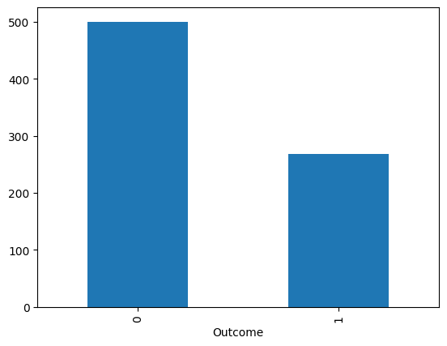

```python
df["Outcome"].value_counts().plot.bar()
plt.show()
```

El primer que mirarem es si "Outcome" que es la nostre variable a predir esta equilibrada i veiem que clarament no ho estan, en concret veiem que tenim casi el doble de punts que no són diavetics a que si que ho son, això ho tindrem que tenir en compte a l'hora d'analitzar les dades

[figure not shown]

```python
df["Pregnancies"].value_counts().plot.bar()
plt.show()
```

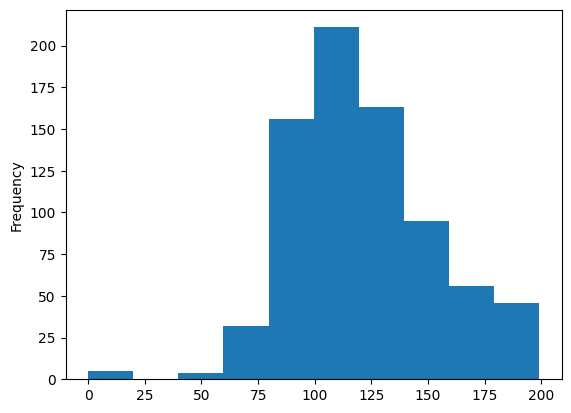

```python
df["Glucose"].plot.hist()
plt.show()
```

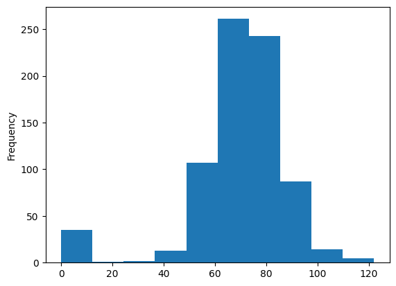

```python
df["BloodPressure"].plot.hist()
plt.show()
```

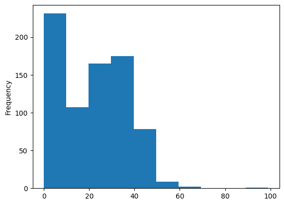

```python
df["SkinThickness"].plot.hist()
plt.show()
```

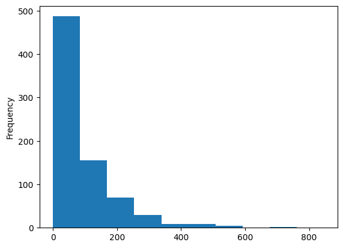

```python
df["Insulin"].plot.hist()
plt.show()
```

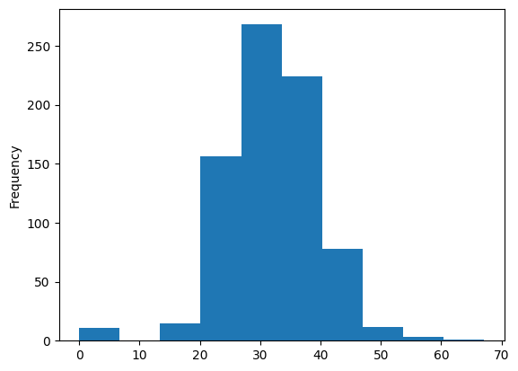

```python
df["BMI"].plot.hist()
plt.show()
```

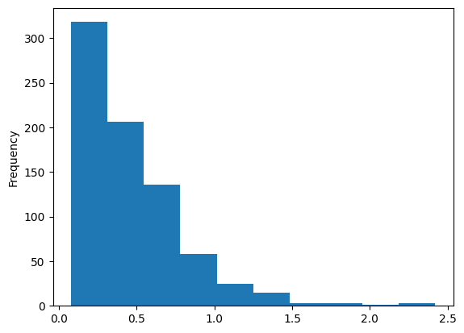

```python
df["DiabetesPedigreeFunction"].plot.hist()
plt.show()
```

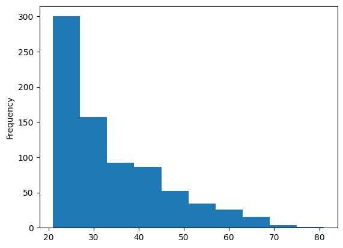

```python
df["Age"].plot.hist()
plt.show()
```

**Implementació:** Realitzi l'anàlisi estadística bàsica.

[output not shown]

Primer estaria ver saber que significa cada variable perque ens ajuradra a entendre les distribucions, buscant l'origen de dades d'aquest model he trobat que les variables signifiquen lo seguent

> 1. Nombre de vegandes que s'ha quedat embaraçada
2. Conentrecia de glucosa en plasma 2 hores despres de un test de tolerancia de glucosa oral
3. Presio de sang diastólica (mm Hg)
4. Gruix de doblec de pell al triceps (mm)
5. 2-horas de serum d'insulina (mu U/ml)
6. Index de masa corporal (pes en kg/(altura en m)^2)
7. Funcio de pedigree en diavetes (Funcin que asigna la probabilitat de tenir diabetes a partir de la historia familiar)
8. Edat (anys)
9. Te o no diabetes

També estaria bé saber quin es el nostre gurp de estudi, i savem que son dones de com a minim 21 anys de origen Pima India. Si comprovem les dades miranrt descrive veiem que el minim es 21 per tant es correcte. Si ara veiem les distribucions veiem que tenim algunes on tenim la acumulaccio de dades al principi y van baixant progresivament com "Age" o "DiabetesPedigreeFunction" i altres que semblen tenir una distribucio normal com "BMI" o "BloodPressure"

- 1.3. Feu una anàlisi exploratòria de dades (EDA) amb visualitzacions per entendre la distribució i correlació.

1.3.1. Analysis of Categorical Variables

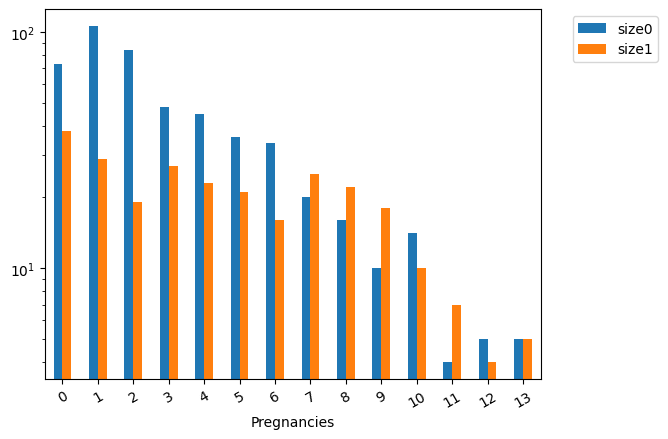

```python
total = df.groupby(by=["Pregnancies", "Outcome"], as_index=False).size()
no = total[total["Outcome"]==0][["Pregnancies","size"]]
yes = total[total["Outcome"]==1][["Pregnancies","size"]]
yes_no = pd.merge(no,yes,on="Pregnancies",suffixes=["0","1"])
ax = yes_no.plot(kind='bar', x='Pregnancies', logy=True, rot=0)
ax.legend(bbox_to_anchor=(1.05, 1), loc='upper left')
plt.xticks(rotation=30)
plt.show()
```

Sembla que tenir més fills fa que sigui més probable que tinguis diavetes, pero també veiem que esta molt correlacionat amb la edad, ja que per tenir més fills has de ser més gran ja que els embaraços durant un temps.

1.3.2. Analysis of Numerical Variables

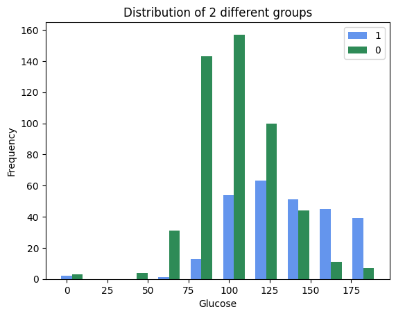

```python
data = df[["Glucose","Outcome"]]
colors = ['purple', 'orange']
group_name = data['Outcome'].unique()

fig, ax = plt.subplots()

a_heights, a_bins = np.histogram(data[data['Outcome']==1]['Glucose'])
b_heights, b_bins = np.histogram(data[data['Outcome']==0]['Glucose'], bins=a_bins)

width = (a_bins[1] - a_bins[0])/3

ax.bar(a_bins[:-1], a_heights, width=width, facecolor='cornflowerblue')
ax.bar(b_bins[:-1]+width, b_heights, width=width, facecolor='seagreen')
# Add a legend
ax.legend(group_name)

# Add a title and axis label
ax.set_title('Distribution of 2 different groups')
ax.set_xlabel('Glucose')
ax.set_ylabel('Frequency')

# Show the plot
plt.show()
```

Tindre una glucosa alta també sebla ser un indicador ja que si la tens alta despres de dos hores pot indicar que no la regules bé i claramant es un sintoma de diabetes

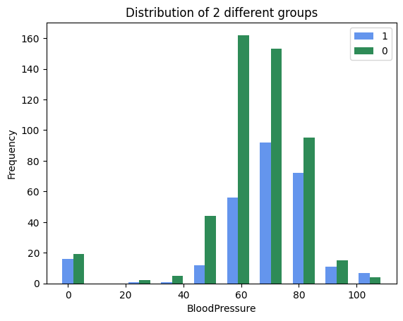

```python
data = df[["BloodPressure","Outcome"]]
colors = ['purple', 'orange']
group_name = data['Outcome'].unique()

fig, ax = plt.subplots()

a_heights, a_bins = np.histogram(data[data['Outcome']==1]['BloodPressure'])
b_heights, b_bins = np.histogram(data[data['Outcome']==0]['BloodPressure'], bins=a_bins)

width = (a_bins[1] - a_bins[0])/3

ax.bar(a_bins[:-1], a_heights, width=width, facecolor='cornflowerblue')
ax.bar(b_bins[:-1]+width, b_heights, width=width, facecolor='seagreen')
# Add a legend
ax.legend(group_name)

# Add a title and axis label
ax.set_title('Distribution of 2 different groups')
ax.set_xlabel('BloodPressure')
ax.set_ylabel('Frequency')

# Show the plot
plt.show()
```

Una presio alterial alta tambe sembla ser indicador de diavetes cosa que potser es un sintoma i no un indicador ja que la presio alterial alta esta relacionada amb la edad o la obesitat. Coses que veurem que tenen també semblen indicadors de diabetes

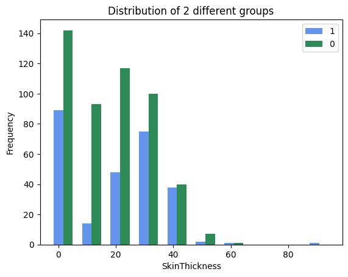

```python
data = df[["SkinThickness","Outcome"]]
colors = ['purple', 'orange']
group_name = data['Outcome'].unique()

fig, ax = plt.subplots()

a_heights, a_bins = np.histogram(data[data['Outcome']==1]['SkinThickness'])
b_heights, b_bins = np.histogram(data[data['Outcome']==0]['SkinThickness'], bins=a_bins)

width = (a_bins[1] - a_bins[0])/3

ax.bar(a_bins[:-1], a_heights, width=width, facecolor='cornflowerblue')
ax.bar(b_bins[:-1]+width, b_heights, width=width, facecolor='seagreen')
# Add a legend
ax.legend(group_name)

# Add a title and axis label
ax.set_title('Distribution of 2 different groups')
ax.set_xlabel('SkinThickness')
ax.set_ylabel('Frequency')

# Show the plot
plt.show()
```

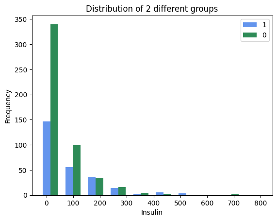

```python
data = df[["Insulin","Outcome"]]
colors = ['purple', 'orange']
group_name = data['Outcome'].unique()

fig, ax = plt.subplots()

a_heights, a_bins = np.histogram(data[data['Outcome']==1]['Insulin'])
b_heights, b_bins = np.histogram(data[data['Outcome']==0]['Insulin'], bins=a_bins)

width = (a_bins[1] - a_bins[0])/3

ax.bar(a_bins[:-1], a_heights, width=width, facecolor='cornflowerblue')
ax.bar(b_bins[:-1]+width, b_heights, width=width, facecolor='seagreen')
# Add a legend
ax.legend(group_name)

# Add a title and axis label
ax.set_title('Distribution of 2 different groups')
ax.set_xlabel('Insulin')
ax.set_ylabel('Frequency')

# Show the plot
plt.show()
```

La insulina també sembla ser una variable que pot ser un marcador de diabetes però el problema que tenim es que la majoria de mostres estan en el mateix espai per tant es dificil saber

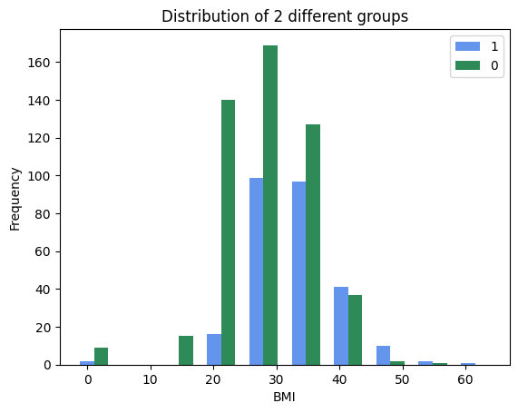

```python
data = df[["BMI","Outcome"]]
colors = ['purple', 'orange']
group_name = data['Outcome'].unique()

fig, ax = plt.subplots()

a_heights, a_bins = np.histogram(data[data['Outcome']==1]['BMI'])
b_heights, b_bins = np.histogram(data[data['Outcome']==0]['BMI'], bins=a_bins)

width = (a_bins[1] - a_bins[0])/3

ax.bar(a_bins[:-1], a_heights, width=width, facecolor='cornflowerblue')
ax.bar(b_bins[:-1]+width, b_heights, width=width, facecolor='seagreen')
# Add a legend
ax.legend(group_name)

# Add a title and axis label
ax.set_title('Distribution of 2 different groups')
ax.set_xlabel('BMI')
ax.set_ylabel('Frequency')

# Show the plot
plt.show()
```

Un bmi alt sembla que pot ser un indicador de diabetes, pero un bmi baix sembla que claramant indica que no sera diabetic

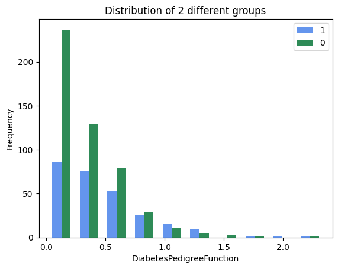

```python
data = df[["DiabetesPedigreeFunction","Outcome"]]
colors = ['purple', 'orange']
group_name = data['Outcome'].unique()

fig, ax = plt.subplots()

a_heights, a_bins = np.histogram(data[data['Outcome']==1]['DiabetesPedigreeFunction'])
b_heights, b_bins = np.histogram(data[data['Outcome']==0]['DiabetesPedigreeFunction'], bins=a_bins)

width = (a_bins[1] - a_bins[0])/3

ax.bar(a_bins[:-1], a_heights, width=width, facecolor='cornflowerblue')
ax.bar(b_bins[:-1]+width, b_heights, width=width, facecolor='seagreen')
# Add a legend
ax.legend(group_name)

# Add a title and axis label
ax.set_title('Distribution of 2 different groups')
ax.set_xlabel('DiabetesPedigreeFunction')
ax.set_ylabel('Frequency')

# Show the plot
plt.show()
```

Sembla que tenim més probabilitat de diabetes si es més gran ja que les dues decreixen pero la de diabeties decreix molt menys que l'altre encara que no podriem assegurar res nomes amb aquest valor, això pot tenir sentit ja que si no es totalment hereditaria potser amb si la persona es cuida pot evitar-se

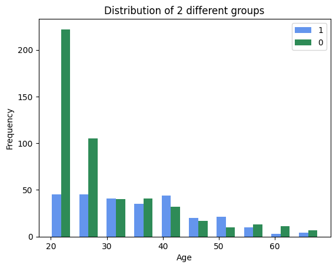

```python
data = df[["Age","Outcome"]]
colors = ['purple', 'orange']
group_name = data['Outcome'].unique()

fig, ax = plt.subplots()

a_heights, a_bins = np.histogram(data[data['Outcome']==1]['Age'])
b_heights, b_bins = np.histogram(data[data['Outcome']==0]['Age'], bins=a_bins)

width = (a_bins[1] - a_bins[0])/3

ax.bar(a_bins[:-1], a_heights, width=width, facecolor='cornflowerblue')
ax.bar(b_bins[:-1]+width, b_heights, width=width, facecolor='seagreen')
# Add a legend
ax.legend(group_name)

# Add a title and axis label
ax.set_title('Distribution of 2 different groups')
ax.set_xlabel('Age')
ax.set_ylabel('Frequency')

# Show the plot
plt.show()
```

Sembla que contra mes jove ets menys probable es que tinguis diavetes

1.3.3. Correlation Matrix

```python
df.corr()
```

|  | Pregnancies | Glucose | BloodPressure | SkinThickness | Insulin | BMI | DiabetesPedigreeFunction | Age | Outcome |
| --- | --- | --- | --- | --- | --- | --- | --- | --- | --- |
| Pregnancies | 1.000000 | 0.129459 | 0.141282 | -0.081672 | -0.073535 | 0.017683 | -0.033523 | 0.544341 | 0.221898 |
| Glucose | 0.129459 | 1.000000 | 0.152590 | 0.057328 | 0.331357 | 0.221071 | 0.137337 | 0.263514 | 0.466581 |
| BloodPressure | 0.141282 | 0.152590 | 1.000000 | 0.207371 | 0.088933 | 0.281805 | 0.041265 | 0.239528 | 0.065068 |
| SkinThickness | -0.081672 | 0.057328 | 0.207371 | 1.000000 | 0.436783 | 0.392573 | 0.183928 | -0.113970 | 0.074752 |
| Insulin | -0.073535 | 0.331357 | 0.088933 | 0.436783 | 1.000000 | 0.197859 | 0.185071 | -0.042163 | 0.130548 |
| BMI | 0.017683 | 0.221071 | 0.281805 | 0.392573 | 0.197859 | 1.000000 | 0.140647 | 0.036242 | 0.292695 |
| DiabetesPedigreeFunction | -0.033523 | 0.137337 | 0.041265 | 0.183928 | 0.185071 | 0.140647 | 1.000000 | 0.033561 | 0.173844 |
| Age | 0.544341 | 0.263514 | 0.239528 | -0.113970 | -0.042163 | 0.036242 | 0.033561 | 1.000000 | 0.238356 |
| Outcome | 0.221898 | 0.466581 | 0.065068 | 0.074752 | 0.130548 | 0.292695 | 0.173844 | 0.238356 | 1.000000 |

Si veiem la edad esta bastant correlacionada amb la quantitar d'embarassos es bastant evident el perque ja que els embarassos tardan temps, ja que com a minim han de pasar els 9 mesos per la concepcio per tant es normal que estiguin molt correlacionades, Despres veiem com la glucosa esta relacionada amb la insulina, cosa que te senit ja que nivells baixos de insulina poden probocar hypoglucemia

Despres veiem com la presio arterial esta lleugerament vincilada a la edat o el BMI, cosa que te senit ja que la presio arterial sol se un sintoma comu en obesitat o en persones grans

el gruix de pell esta molt correlacionat amb BMI ja que els dos solen ser probes per confirmar obesitat, també esta molt correlacionat amb la insuilina

- 1.4. Preprocessament de dades:

**Implementació:** Netegeu i preprocessament les dades, incloent-hi el tractament de valors perduts i valors atípics.

```python
df.isnull().values.any()
```

```
False
```

Pero hi ha valors que no son nuls que clarament son incorrectes, tenir glucosa, bloodpressure o bmi ja que els dos primers a zero no te sentit per tant eliminarem aquest casos. Ja que ens els dos primers si tens glucosa 0 o presio arterial 0 estas mort i un bmi de 0 implicaria que peses 0 que també es imposible

```python
# Clean values
df = df[df["Glucose"]!=0]
df = df[df["BloodPressure"]!=0]
df = df[df["BMI"]!=0]
```

- 1.5. Balanç de classes

**Implementació:** Verificació de classes.

Atès que tenim previst utilitzar xarxes neuronals i transfer learning (que pot gestionar bé grans conjunts de dades), el millor mètode seria una combinació de **SMOTE** i **ADASYN**:

- Primer utilitza **SMOTE**. Ajudarà a crear un conjunt de dades equilibrat amb mostres sintètiques (random_state=42).
- Després **ADASYN**. Perfeccionarà encara més les dades sintètiques, centrant-se en les mostres desafiants (random_state=42).

**Implementació:** Realitzi l'anàlisi de balanç de classes.

```python
# Separate features (X) and target variable (y)
X = df.drop('Outcome', axis=1)
y = df['Outcome']
# Apply SMOTE
smote = SMOTE(random_state=42)
X_smote, y_smote = smote.fit_resample(X, y)

# Apply ADASYN
adasyn = ADASYN(random_state=42)
X_resampled, y_resampled = adasyn.fit_resample(X_smote, y_smote)
```

**Implementació:** Crea un nou DataFrame per a les dades remostrades.

```python
# Create a new balanced DataFrame
df_balanced = pd.DataFrame(X_resampled, columns=X.columns)
df_balanced['Outcome'] = y_resampled
```

### **2. Reducció de Dimensionalitat (1 punt)**

En aquesta part de la PAC, utilitzarem **Anàlisi de Components Principals (PCA)** per millorar la informació dels pacients diabètics amb l'objectiu de facilitar la separació en el model de classificació. El nostre objectiu és garantir que el model PCA capturi patrons útils per distingir millor els pacients diabètics dels no diabètics.

**Riscos d'Overfitting i Com Evitar-los:**

Quan construïm el model PCA només amb pacients diabètics, pot existir el risc que els components principals capturin patrons específics d'aquest grup i no es generalitzin bé per als pacients no diabètics. Per mitigar aquest risc, seguirem un enfocament robust amb **validació creuada**, el qual:

1. **Mitjana el sobreajustament**, avaluant la estabilitat dels components principals a través de diferents particions de dades de pacients diabètics.
2. **Garanteix una millor generalització**, ja que seleccionem un conjunt estable de components mitjançant l'**averiguació de les càrregues** dels components principals a través dels diferents plegaments (folds) de la validació creuada.

### **Procés Recomanat**

1. **Preparació:** Es separen els pacients diabètics per a l'entrenament del PCA. Divideix les dades diabètiques en entrenament/validació (80%) i proves (20%), random_state=42.
2. **Normalització i Validació Creuada per al PCA:** Utilitzem validació creuada (n_splits=5, shuffle=True, random_state=42) per normalitzar les dades i avaluar la consistència dels components principals.
3. **Averiguació dels Components Principals:** Es fa la mitjana de les càrregues dels components principals per obtenir un conjunt estable.
4. **Projecció de les Dades Restants:** Utilitzem els components estables per projectar tant les dades de test dels pacients diabètics com les dades dels pacients no diabètics.
5. **Creació del Conjunt d'Entrenament per a Classificació:** El conjunt de dades projectat s'utilitza com a entrada per als models de classificació.

Aquest enfocament garanteix que el model PCA no sobreajusti als pacients diabètics utilitzats per construir-lo, i ens permet utilitzar descriptors coherents per a tot el conjunt de dades. Això millora la robustesa del model de classificació, minimitzant el risc de biaix i millorant la separació dels pacients en base a les seves característiques projectades.

- 2.1. Preparació.

**Implementació:** Preparació: Se separen els pacients diabètics per a l'entrenament del PCA. Divideix les dades diabètiques en entrenament/validació (80%) i proves (20%), random state=42.

```python
# Split between diavetic and non diavetic
diavetic = df_balanced[df_balanced["Outcome"]==1]
non_diavetic = df_balanced[df_balanced["Outcome"]==0]

# Split data into training and validation sets
X_train, X_valid, y_train, y_valid = train_test_split(
    diavetic.drop('Outcome', axis=1),
    diavetic['Outcome'],
    test_size=0.2,
    random_state=42
)
```

- 2.2. Normalització i construcció del model PCA:

**Implementació:** Normalització i construcció del model PCA: Es normalitzen les dades i es crea el model dels components principals amb el conjunt de pacients d'entrenament del pas anterior (diabètics) amb el 95% de variància retinguda.

```python
# Normalize the data
scaler = StandardScaler()
X_train_scaled = scaler.fit_transform(X_train)

# Apply PCA with 95% variance explained
pca = PCA(n_components=0.95, random_state=42)
X_train_pca = pca.fit_transform(X_train_scaled)

pca.n_components_
```

```
8
```

Si mirem la documentacio

> if 0 < n_components < 1 and svd_solver == ‘full’, select the number of components such that the amount of variance that needs to be explained is greater than the percentage specified by n_components

per tant el numero de components necesaris per tenir 95 % hauria de ser 8 pero això son totes les variables, per tant intentarem 7 i veurem com es la variança

```python
pca_loadings = []
kf = KFold(n_splits=5, shuffle=True, random_state=42)

for train_index, val_index in kf.split(X_train_scaled):
    X_train_fold, X_val_fold = X_train_scaled[train_index], X_train_scaled[val_index]

    # Normalize the data for the current fold
    scaler_fold = StandardScaler()
    X_train_fold_scaled = scaler_fold.fit_transform(X_train_fold)
    X_val_fold_scaled = scaler_fold.transform(X_val_fold)

    pca_fold = PCA(n_components=7)  # Apply PCA to each fold
    pca_fold.fit(X_train_fold_scaled)
    print ( "Components = ", pca_fold.n_components_ , ";\nTotal explained variance = ",
      round(pca_fold.explained_variance_ratio_.sum(),5)  )
    pca_loadings.append(round(pca_fold.explained_variance_ratio_.sum(),5))
print("The average of the explained variance = " , round(np.mean(pca_loadings),5))
```

```
Components =  7 ;
Total explained variance =  0.95473
Components =  7 ;
Total explained variance =  0.95337
Components =  7 ;
Total explained variance =  0.95626
Components =  7 ;
Total explained variance =  0.95541
Components =  7 ;
Total explained variance =  0.96037
The average of the explained variance =  0.95603
```

Per tant comprovem que 7 es un numero adecuat

```python
# Apply PCA with 7 components
pca = PCA(n_components=7, random_state=42)
X_train_pca = pca.fit_transform(X_train_scaled)
```

**Implementació:** Realitzi les gràfiques que consideri necessàries.

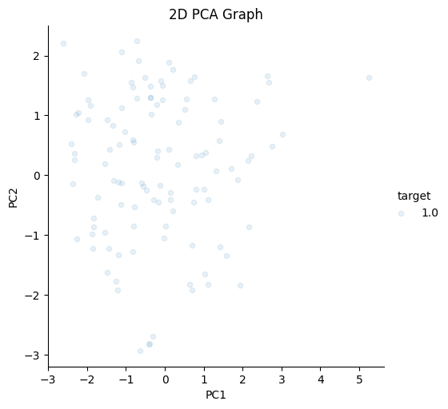

```python
import seaborn as sns
from sklearn.decomposition import PCA

pca_df = pd.DataFrame(
    data=X_train_pca[:, 0:2],
    columns=['PC1', 'PC2'])
pca_df['target'] = y_train
sns.lmplot(
    x='PC1',
    y='PC2',
    data=pca_df,
    hue='target',
    fit_reg=False,
    legend=True,
    scatter_kws={'alpha': 0.1,"s": 20}
    )

plt.title('2D PCA Graph')
plt.show()
```

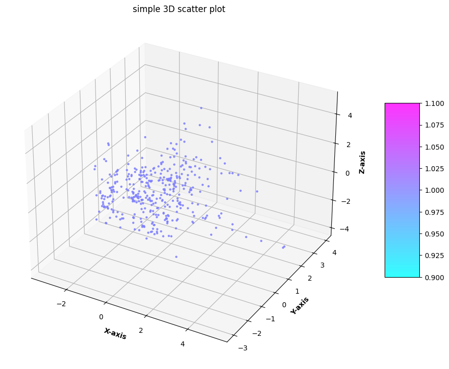

```python
fig = plt.figure(figsize = (16, 9))
ax = plt.axes(projection ="3d")

# Add x, y gridlines
ax.grid(b = True, color ='grey',
        linestyle ='-.', linewidth = 0.3,
        alpha = 0.2)


my_cmap = plt.get_cmap('cool')

# Creating plot
sctt = ax.scatter3D(X_train_pca[:, 0], X_train_pca[:, 1], X_train_pca[:, 2],
                    alpha = 0.8,
                    c = y_train,
                    cmap = my_cmap,
                   s= 5)

plt.title("simple 3D scatter plot")
ax.set_xlabel('X-axis', fontweight ='bold')
ax.set_ylabel('Y-axis', fontweight ='bold')
ax.set_zlabel('Z-axis', fontweight ='bold')
fig.colorbar(sctt, ax = ax, shrink = 0.5, aspect = 5)

# show plot
plt.show()
```

- 2.3. Projecció de les Dades Restants

En aquest punt, ja hem construït el model PCA utilitzant només les dades dels pacients diagnosticats amb diabetis. Ara, per poder comparar el rendiment dels nostres classificadors de manera consistent, necessitem projectar **totes** les mostres. Tant dades escalades dels pacients amb diabetis (restant 20%) com les dels pacients sense diabetis, sobre aquest mateix model PCA.

##### **Per què projectar totes les dades sobre el mateix model PCA?**

1. **Consistència dels descriptors**:
   - En projectar totes les dades sobre el mateix model PCA, obtenim un conjunt de descriptors uniformes (els components principals) per a tots els pacients, independentment del seu diagnòstic. Això és clau perquè els classificadors treballin amb les mateixes variables d'entrada.
2. **Reducció de la dimensionalitat**:
   - Utilitzar els components principals com a variables d'entrada redueix el nombre de dimensions, la qual cosa facilita l'entrenament dels models i redueix el risc d'overfitting.
3. **Millora de la generalització**:
   - En fer servir descriptors PCA, que són les combinacions lineals de les variables originals més informatives, es millora la capacitat del model per generalitzar a noves dades.

**Implementació:** Projecte les dades restants en el model PCA creat anteriorment.

```python
X_valid_scaled = scaler.transform(X_valid)
X_valid_pca = pca.transform(X_valid_scaled)
# Generate the total
non_diavetic = df_balanced[df_balanced["Outcome"]==0]
X_non_diavetic_scaled = scaler.transform(non_diavetic.drop('Outcome', axis=1))
X_non_diavetic_pca = pca.transform(X_non_diavetic_scaled)
y_non_diavetic = non_diavetic['Outcome']
X_total_pca = np.concatenate((X_train_pca, X_valid_pca, X_non_diavetic_pca), axis=0)
y_total = np.concatenate((y_train, y_valid, y_non_diavetic), axis=0)
```

**Implementació:** Realitzi les gràfiques que consideri necessàries. Ajuda: Realitzi la gràfica en 2D de les dues primeres components principals (o 3D per a les tres primeres). Inclou les dades utilitzades per a entrenar el model (diabètics 80%), el 20% restant de diabètics i els no diabètics. Utilitzi colors distints per a cada grup.

\

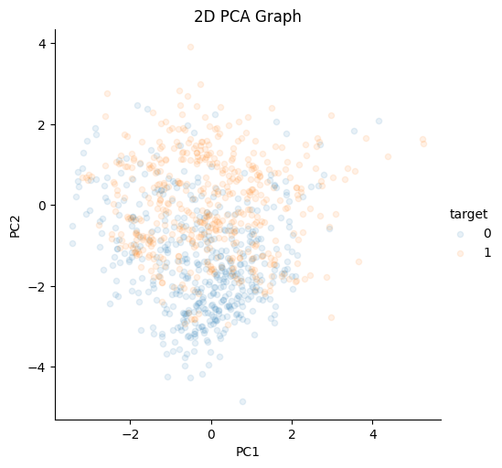

```python
import seaborn as sns
from sklearn.decomposition import PCA

pca_df = pd.DataFrame(
    data=X_total_pca[:, 0:2],
    columns=['PC1', 'PC2'])
pca_df['target'] = y_total
sns.lmplot(
    x='PC1',
    y='PC2',
    data=pca_df,
    hue='target',
    fit_reg=False,
    legend=True,
    scatter_kws={'alpha': 0.1,"s": 20}
    )

plt.title('2D PCA Graph')
plt.show()
```

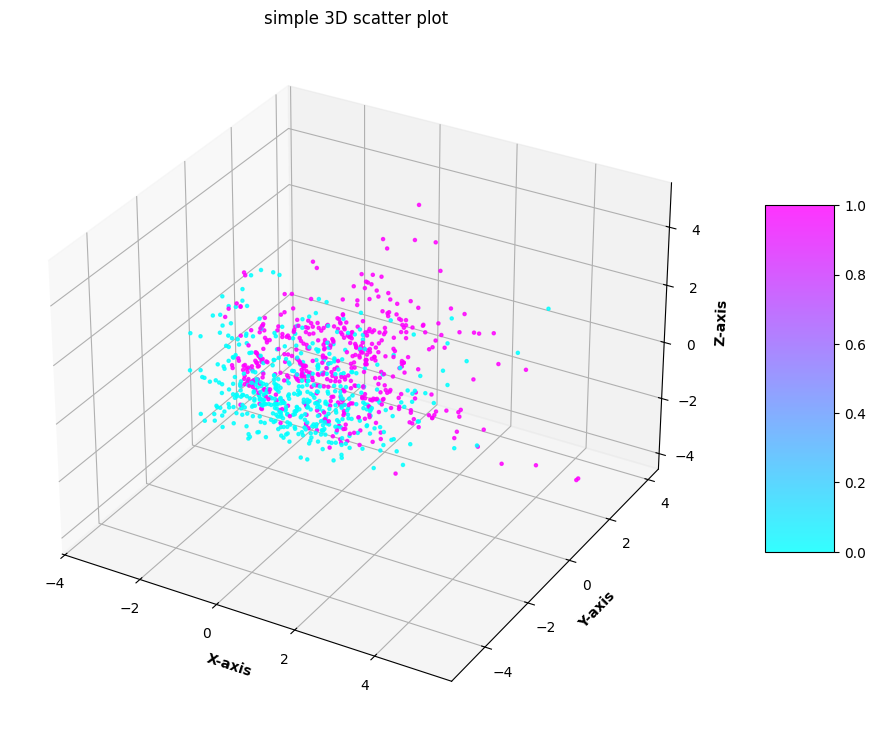

```python
fig = plt.figure(figsize = (16, 9))
ax = plt.axes(projection ="3d")

# Add x, y gridlines
ax.grid(b = True, color ='grey',
        linestyle ='-.', linewidth = 0.3,
        alpha = 0.2)


my_cmap = plt.get_cmap('cool')

# Creating plot
sctt = ax.scatter3D(X_total_pca[:, 0], X_total_pca[:, 1], X_total_pca[:, 2],
                    alpha = 0.8,
                    c = y_total,
                    cmap = my_cmap,
                   s= 5)

plt.title("simple 3D scatter plot")
ax.set_xlabel('X-axis', fontweight ='bold')
ax.set_ylabel('Y-axis', fontweight ='bold')
ax.set_zlabel('Z-axis', fontweight ='bold')
fig.colorbar(sctt, ax = ax, shrink = 0.5, aspect = 5)

# show plot
plt.show()
```

- 2.4. Creació del Conjunt d'Entrenament per a Classificació:

En treballar amb models de PCA utilitzant la llibreria `scikit-learn`, és important entendre que l'objecte del PCA (`pca_final`) **no guarda automàticament els components principals associats a les mostres transformades**. El PCA només manté els components del model (és a dir, les combinacions lineals de les variables originals) i la informació de la variància explicada.

Per això, si voleu conservar els **valors dels components principals (scores)** associats a cada mostra transformada per al seu ús futur, haureu de fer-ho **manualment**, creant un DataFrame separat. Això us permetrà:

1. **Reutilitzar les dades**: Podreu carregar-les directament en el futur sense haver de repetir el càlcul del PCA.
2. **Assegurar la consistència**: Eviteu diferències si el conjunt de dades original canvia o si s'afegeixen noves mostres.
3. **Preparar les dades per a l'anàlisi**: Podeu combinar els scores amb altres variables o utilitzar-los directament en models de classificació.

Consideracions finals:

- Recordeu que aquest procés s'ha de repetir per a qualsevol conjunt de dades que vulgueu projectar al model PCA (diabetic_test_data, non_diabetic_data).
- Aquesta separació us permet mantenir el model PCA enfocat únicament en transformacions i conservar els scores com a dades processades.

Aquesta particularitat pot semblar poc intuïtiva al principi, però assegura que el model es manté modular i fàcil d'utilitzar per a altres transformacions.

**Implementació:** Agrupa en un sol conjunt de dades la projecció de les dades de train dels pacients no diabètics (les que ja s’han utilitzat per entrenar el PCA), el 20% de les dades de test dels pacients diabètics i totes les dades dels pacients no diabètics.

El conjunt de dades resultant conté: * Una columna per a cada projecció de component principal ("PC1", "PC2", ..., "PCn"). * Una columna "Outcome" per identificar si són mostres de diabètics o no.

```python
df_final = pd.DataFrame(
    data=X_total_pca,
    columns=['PC1', 'PC2', 'PC3' , 'PC4', 'PC5', 'PC6', 'PC7'])
df_final['Outcome'] = y_total
df_final.head()
```

|  | PC1 | PC2 | PC3 | PC4 | PC5 | PC6 | PC7 | Outcome |
| --- | --- | --- | --- | --- | --- | --- | --- | --- |
| 0 | -2.079511 | 0.947006 | -1.108692 | -0.049296 | 0.827230 | -0.199351 | -0.527634 | 1 |
| 1 | 2.144342 | -1.439463 | 1.341882 | 0.832373 | 0.120424 | 1.125318 | 0.516239 | 1 |
| 2 | 1.400681 | 0.578093 | 0.375494 | -0.006611 | 0.925913 | -0.098392 | -0.761284 | 1 |
| 3 | 2.614140 | 1.440801 | 1.126711 | 1.644600 | -1.400840 | -0.433211 | -0.388225 | 1 |
| 4 | -0.028524 | -1.051905 | -0.957725 | -0.812109 | -1.213468 | 0.870518 | 0.189207 | 1 |

### 3. Entrenament i Avaluació de Models Base (2.5 punts)

Es formaran quatre models diferents:

- 1. Logistic Regression
- 2. Decision Tree
- 3. Random Forest
- 4. SVM

i cada model serà entrenat utilitzant els dos grups de:

- Les característiques originals
- Les característiques transformades de PCA.

##### 3.1 Entrenament

3.1.1. Característiques originals

Passos a seguir per a les entrades dels de les característiques originals:

- 1. Reuneix les característiques originals en un solo data frame anomenat X i un altre anomenat i per a la sortida o outcome.
- 2. Assigna les etiquetes de classe: Assigna 1 per a mostres diabètiques i 0 per a mostres no diabètiques.
- 3.Divideix les dades: Assegureu que dividiu el conjunt de dades combinat en conjunts d'entrenament (80%) i proves si no ja ho heu fet. Això evita la fugida d'informació de les proves a l'entrenament.
- 4. Models de classificació de formació i avaluació: Utilitza el conjunt de dades per entrenar models que puguin separar les classes diabètiques i no diabètiques.

**Implementació:** Per a les característiques originals, prepari l'entrade X i sortida/outcome y per als classificadors. Divideix 80%-20% per a training i testing.

```python
X_train_total, X_valid_total, y_train_total, y_valid_total = train_test_split(
    df_balanced.drop('Outcome', axis=1),
    df_balanced['Outcome'],
    test_size=0.2,
    random_state=42
)
```

3.1.2. Entrades dels components principals

Aquest és el moment on utilitzaràs les principals components que has emmagatzemat anteriorment de PCA. Passos a seguir per a les entrades dels components principals:

- 1. Combina els components principals diabètics i no diabètics: Combina els components principals de les dades diabètiques (entrenament i proves) i no diabètiques en un únic conjunt de dades per a la classificació.
- 2. Assigna les etiquetes de classe: Assigna 1 per a mostres diabètiques i 0 per a mostres no diabètiques.
- 3.Divideix les dades combinades: Assegureu que dividiu el conjunt de dades combinat en conjunts d'entrenament (80%) i proves si no ja ho heu fet. Això evita la fugida d'informació de les proves a l'entrenament.
- 4. Models de classificació de formació i avaluació: Utilitza el conjunt de dades per entrenar models per separar eficaçment les classes diabètiques i no diabètiques.

**Implementació:** Per a les característiques transformades de PCA, prepari l'entrade X i sortida/outcome y per als classificadors. Divideix 80%-20% per a training i testing.

```python
X_train_PCA, X_valid_PCA, y_train_PCA, y_valid_PCA = train_test_split(
    df_final.drop('Outcome', axis=1),
    df_final['Outcome'],
    test_size=0.2,
    random_state=42
)
```

- 3.2. Entrenament dels models de classificació de les variables originals

**Implementació:** Entreneu models base amb les variables originals com a descriptors i Avalueu els models utilitzant mètriques d'exactitud, sensibilitat, especificitat, ROC-AUC i anàlisi de la matriu de confusió.

```python
# Logistic Regression
logreg = LogisticRegression(random_state=42, max_iter=1000)
logreg.fit(X_train_total, y_train_total)
y_pred_logreg = logreg.predict(X_valid_total)

# Evaluate the model
accuracy_logreg = accuracy_score(y_valid_total, y_pred_logreg)
cm_logreg = confusion_matrix(y_valid_total, y_pred_logreg)
sensitivity_logreg = cm_logreg[1, 1] / (cm_logreg[1, 0] + cm_logreg[1, 1])
specificity_logreg = cm_logreg[0, 0] / (cm_logreg[0, 0] + cm_logreg[0, 1])
roc_auc_logreg = roc_auc_score(y_valid_total, logreg.predict_proba(X_valid_total)[:, 1])

print("Logistic Regression - Original Features")
print(f"Accuracy: {accuracy_logreg}")
print(f"Sensitivity: {sensitivity_logreg}")
print(f"Specificity: {specificity_logreg}")
print(f"ROC-AUC: {roc_auc_logreg}")
print("Confusion Matrix:")
print(cm_logreg)
print(classification_report(y_valid_total, y_pred_logreg))
```

```
Logistic Regression - Original Features
Accuracy: 0.7
Sensitivity: 0.7222222222222222
Specificity: 0.68
ROC-AUC: 0.7897777777777777
Confusion Matrix:
[[68 32]
 [25 65]]
              precision    recall  f1-score   support

           0       0.73      0.68      0.70       100
           1       0.67      0.72      0.70        90

    accuracy                           0.70       190
   macro avg       0.70      0.70      0.70       190
weighted avg       0.70      0.70      0.70       190
```

```python
# Decision Tree
destree = DecisionTreeClassifier(random_state=42, )
destree.fit(X_train_total, y_train_total)
y_pred_destree = destree.predict(X_valid_total)

# Evaluate the model
accuracy_destree = accuracy_score(y_valid_total, y_pred_destree)
cm_destree = confusion_matrix(y_valid_total, y_pred_destree)
sensitivity_destree = cm_destree[1, 1] / (cm_destree[1, 0] + cm_destree[1, 1])
specificity_destree = cm_destree[0, 0] / (cm_destree[0, 0] + cm_destree[0, 1])
roc_auc_destree = roc_auc_score(y_valid_total, destree.predict_proba(X_valid_total)[:, 1])

print("Decision Tree - Original Features")
print(f"Accuracy: {accuracy_destree}")
print(f"Sensitivity: {sensitivity_destree}")
print(f"Specificity: {specificity_destree}")
print(f"ROC-AUC: {roc_auc_destree}")
print("Confusion Matrix:")
print(cm_destree)
print(classification_report(y_valid_total, y_pred_destree))
```

```
Decision Tree - Original Features
Accuracy: 0.7421052631578947
Sensitivity: 0.7888888888888889
Specificity: 0.7
ROC-AUC: 0.7444444444444444
Confusion Matrix:
[[70 30]
 [19 71]]
              precision    recall  f1-score   support

           0       0.79      0.70      0.74       100
           1       0.70      0.79      0.74        90

    accuracy                           0.74       190
   macro avg       0.74      0.74      0.74       190
weighted avg       0.75      0.74      0.74       190
```

```python
# Random Forest
randfores = RandomForestClassifier(random_state=42)
randfores.fit(X_train_total, y_train_total)
y_pred_randfores = randfores.predict(X_valid_total)

# Evaluate the model
accuracy_randfores = accuracy_score(y_valid_total, y_pred_randfores)
cm_randfores = confusion_matrix(y_valid_total, y_pred_randfores)
sensitivity_randfores = cm_randfores[1, 1] / (cm_randfores[1, 0] + cm_randfores[1, 1])
specificity_randfores = cm_randfores[0, 0] / (cm_randfores[0, 0] + cm_randfores[0, 1])
roc_auc_randfores = roc_auc_score(y_valid_total, randfores.predict_proba(X_valid_total)[:, 1])

print("Random Forest - Original Features")
print(f"Accuracy: {accuracy_randfores}")
print(f"Sensitivity: {sensitivity_randfores}")
print(f"Specificity: {specificity_randfores}")
print(f"ROC-AUC: {roc_auc_randfores}")
print("Confusion Matrix:")
print(cm_randfores)
print(classification_report(y_valid_total, y_pred_randfores))
```

[output not shown]

```python
# Suport Vector Machine
svm_model = SVC(random_state=42)
svm_model.fit(X_train_total, y_train_total)
y_pred_svm_model = svm_model.predict(X_valid_total)

# Evaluate the model
accuracy_svm_model = accuracy_score(y_valid_total, y_pred_svm_model)
cm_svm_model = confusion_matrix(y_valid_total, y_pred_svm_model)
sensitivity_svm_model = cm_svm_model[1, 1] / (cm_svm_model[1, 0] + cm_svm_model[1, 1])
specificity_svm_model = cm_svm_model[0, 0] / (cm_svm_model[0, 0] + cm_svm_model[0, 1])
roc_auc_svm_model = roc_auc_score(y_valid_total, y_pred_svm_model)

print("Suport Vector Machine - Original Features")
print(f"Accuracy: {accuracy_svm_model}")
print(f"Sensitivity: {sensitivity_svm_model}")
print(f"Specificity: {specificity_svm_model}")
print(f"ROC-AUC: {roc_auc_svm_model}")
print("Confusion Matrix:")
print(cm_svm_model)
print(classification_report(y_valid_total, y_pred_svm_model))
```

```
Suport Vector Machine - Original Features
Accuracy: 0.6894736842105263
Sensitivity: 0.7222222222222222
Specificity: 0.66
ROC-AUC: 0.691111111111111
Confusion Matrix:
[[66 34]
 [25 65]]
              precision    recall  f1-score   support

           0       0.73      0.66      0.69       100
           1       0.66      0.72      0.69        90

    accuracy                           0.69       190
   macro avg       0.69      0.69      0.69       190
weighted avg       0.69      0.69      0.69       190
```

- 3.3. Entrenament dels models de classificació de les variables amb els components principals (PCs)

**Implementació:** Entreneu models base amb els components principals (PCs) com a descriptors i Avalueu els models utilitzant mètriques d'exactitud, sensibilitat, especificitat, ROC-AUC i anàlisi de la matriu de confusió.

```python
# Logistic Regression with PCA
logreg_pca = LogisticRegression(random_state=42, max_iter=1000)
logreg_pca.fit(X_train_PCA, y_train_PCA)
y_pred_logreg_pca = logreg_pca.predict(X_valid_PCA)

# Evaluate the model
accuracy_logreg_pca = accuracy_score(y_valid_PCA, y_pred_logreg_pca)
cm_logreg_pca = confusion_matrix(y_valid_PCA, y_pred_logreg_pca)
sensitivity_logreg_pca = cm_logreg_pca[1, 1] / (cm_logreg_pca[1, 0] + cm_logreg_pca[1, 1])
specificity_logreg_pca = cm_logreg_pca[0, 0] / (cm_logreg_pca[0, 0] + cm_logreg_pca[0, 1])
roc_auc_logreg_pca = roc_auc_score(y_valid_PCA, logreg_pca.predict_proba(X_valid_PCA)[:, 1])

print("\nLogistic Regression - PCA Features")
print(f"Accuracy: {accuracy_logreg_pca}")
print(f"Sensitivity: {sensitivity_logreg_pca}")
print(f"Specificity: {specificity_logreg_pca}")
print(f"ROC-AUC: {roc_auc_logreg_pca}")
print("Confusion Matrix:")
print(cm_logreg_pca)
print(classification_report(y_valid_PCA, y_pred_logreg_pca))
```

```
Logistic Regression - PCA Features
Accuracy: 0.7736842105263158
Sensitivity: 0.7608695652173914
Specificity: 0.7857142857142857
ROC-AUC: 0.8700088731144632
Confusion Matrix:
[[77 21]
 [22 70]]
              precision    recall  f1-score   support

           0       0.78      0.79      0.78        98
           1       0.77      0.76      0.77        92

    accuracy                           0.77       190
   macro avg       0.77      0.77      0.77       190
weighted avg       0.77      0.77      0.77       190
```

```python
# Decision Tree with PCA
destree_pca = DecisionTreeClassifier(random_state=42)
destree_pca.fit(X_train_PCA, y_train_PCA)
y_pred_destree_pca = destree_pca.predict(X_valid_PCA)

# Evaluate the model
accuracy_destree_pca = accuracy_score(y_valid_PCA, y_pred_destree_pca)
cm_destree_pca = confusion_matrix(y_valid_PCA, y_pred_destree_pca)
sensitivity_destree_pca = cm_destree_pca[1, 1] / (cm_destree_pca[1, 0] + cm_destree_pca[1, 1])
specificity_destree_pca = cm_destree_pca[0, 0] / (cm_destree_pca[0, 0] + cm_destree_pca[0, 1])
roc_auc_destree_pca = roc_auc_score(y_valid_PCA, destree_pca.predict_proba(X_valid_PCA)[:, 1])

print("\n Decision Tree - PCA Features")
print(f"Accuracy: {accuracy_destree_pca}")
print(f"Sensitivity: {sensitivity_destree_pca}")
print(f"Specificity: {specificity_destree_pca}")
print(f"ROC-AUC: {roc_auc_destree_pca}")
print("Confusion Matrix:")
print(cm_destree_pca)
print(classification_report(y_valid_PCA, y_pred_destree_pca))
```

```
 Decision Tree - PCA Features
Accuracy: 0.7
Sensitivity: 0.6956521739130435
Specificity: 0.7040816326530612
ROC-AUC: 0.6998669032830525
Confusion Matrix:
[[69 29]
 [28 64]]
              precision    recall  f1-score   support

           0       0.71      0.70      0.71        98
           1       0.69      0.70      0.69        92

    accuracy                           0.70       190
   macro avg       0.70      0.70      0.70       190
weighted avg       0.70      0.70      0.70       190
```

```python
# Random Forest with PCA
randfores_pca = RandomForestClassifier(random_state=42)
randfores_pca.fit(X_train_PCA, y_train_PCA)
y_pred_randfores_pca = randfores_pca.predict(X_valid_PCA)

# Evaluate the model
accuracy_randfores_pca = accuracy_score(y_valid_PCA, y_pred_randfores_pca)
cm_randfores_pca = confusion_matrix(y_valid_PCA, y_pred_randfores_pca)
sensitivity_randfores_pca = cm_randfores_pca[1, 1] / (cm_randfores_pca[1, 0] + cm_randfores_pca[1, 1])
specificity_randfores_pca = cm_randfores_pca[0, 0] / (cm_randfores_pca[0, 0] + cm_randfores_pca[0, 1])
roc_auc_randfores_pca = roc_auc_score(y_valid_PCA, randfores_pca.predict_proba(X_valid_PCA)[:, 1])

print("\n Random Forest - PCA Features")
print(f"Accuracy: {accuracy_randfores_pca}")
print(f"Sensitivity: {sensitivity_randfores_pca}")
print(f"Specificity: {specificity_randfores_pca}")
print(f"ROC-AUC: {roc_auc_randfores_pca}")
print("Confusion Matrix:")
print(cm_randfores_pca)
print(classification_report(y_valid_PCA, y_pred_randfores_pca))
```

```
 Random Forest - PCA Features
Accuracy: 0.8105263157894737
Sensitivity: 0.8152173913043478
Specificity: 0.8061224489795918
ROC-AUC: 0.8961845607808341
Confusion Matrix:
[[79 19]
 [17 75]]
              precision    recall  f1-score   support

           0       0.82      0.81      0.81        98
           1       0.80      0.82      0.81        92

    accuracy                           0.81       190
   macro avg       0.81      0.81      0.81       190
weighted avg       0.81      0.81      0.81       190
```

```python
# Suport Vector Machine with PCA
svm_model_pca = SVC(random_state=42)
svm_model_pca.fit(X_train_PCA, y_train_PCA)
y_pred_svm_model_pca = svm_model_pca.predict(X_valid_PCA)

# Evaluate the model
accuracy_svm_model_pca = accuracy_score(y_valid_PCA, y_pred_svm_model_pca)
cm_svm_model_pca = confusion_matrix(y_valid_PCA, y_pred_svm_model_pca)
sensitivity_svm_model_pca = cm_svm_model_pca[1, 1] / (cm_svm_model_pca[1, 0] + cm_svm_model_pca[1, 1])
specificity_svm_model_pca = cm_svm_model_pca[0, 0] / (cm_svm_model_pca[0, 0] + cm_svm_model_pca[0, 1])
roc_auc_svm_model_pca = roc_auc_score(y_valid_PCA, y_pred_svm_model_pca)

print("\n Suport Vector Machine - PCA Features")
print(f"Accuracy: {accuracy_svm_model_pca}")
print(f"Sensitivity: {sensitivity_svm_model_pca}")
print(f"Specificity: {specificity_svm_model_pca}")
print(f"ROC-AUC: {roc_auc_svm_model_pca}")
print("Confusion Matrix:")
print(cm_svm_model_pca)
print(classification_report(y_valid_PCA, y_pred_svm_model_pca))
```

```
 Suport Vector Machine - PCA Features
Accuracy: 0.7842105263157895
Sensitivity: 0.8043478260869565
Specificity: 0.7653061224489796
ROC-AUC: 0.784826974267968
Confusion Matrix:
[[75 23]
 [18 74]]
              precision    recall  f1-score   support

           0       0.81      0.77      0.79        98
           1       0.76      0.80      0.78        92

    accuracy                           0.78       190
   macro avg       0.78      0.78      0.78       190
weighted avg       0.79      0.78      0.78       190
```

- 3.4 Anàlisi de resultats

**Anàlisi:** Analitzi els resultats utilitzant les variables originals com a entrades a les eines de classificació i els resultats utilitzant les principals components o variables latents com a entrades a les mateixes eines de classificació.

Veiem que en general tots utilitzant PCA funcionen millor que amb les variables originals (nomes Decision Tree funciona pitjor) tenit en compte que tenim menys variables per predir això es un avens ja que amb menys dades estem donant un millor resultat. També en aquest cas ens interesa més la sensivitat ja que volem diagnostigar una enfermetat es molt important no tenir falsos negatius ja que això podria probocar que algu que necesiti tractament no l'estigui rebent tenint en compte això veiem que el millor model es Random forest, i si mirem nomes la sensitivitat es millor amb les variables originals, ja que encara que predeixi millor amb pca sembla que amb original features la sensitivitat es millor.

### **4. Tècniques Avançades d'Ensemble (3 punts)**

- 4.1. Implementeu i avalueu tècniques d'ensemble com Bagging, Boosting, Stacking i Cascading utilitzant les variables originals.
- 4.2. Repetiu la implementació amb els components principals com a descriptors.
- 4.3. Compareu el rendiment de cada mètode i analitzeu-ne els resultats.

Per a aplicar l'ensamble learning us proposem seguir els següents passos:

**1. Classe `CascadingClassifier`**

###### **Propòsit:**

- Implementa una tècnica personalitzada d'aprenentatge ensemble on les prediccions d'un primer model (`base_model1`) s'afegeixen com a característiques addicionals a les dades d'entrada per a un segon model (`base_model2`).

###### **Components clau:**

- **Mètode `__init__`:**
  - Inicialitza el classificador amb dos models base.
- **Mètode `fit`:**
  - Entrena el `base_model1` amb les característiques d'entrada (`X`) i les etiquetes (`y`).
  - Genera les prediccions del `base_model1` i les afegeix com una nova columna a les característiques d'entrada.
  - Entrena el `base_model2` amb aquest conjunt de dades augmentat.
- **Mètode `predict`:**
  - Utilitza el `base_model1` entrenat per predir les etiquetes de les dades d'entrada.
  - Augmenta les característiques d'entrada amb aquestes prediccions i les passa al `base_model2` per obtenir les prediccions finals.
- **Mètode `predict_proba`:**
  - Similar a `predict`, però retorna les probabilitats de classe per a les dades d'entrada.

###### **Llibreries i tècniques clau:**

- **`np.hstack`:** Combina arrays per columnes per afegir les prediccions com a característiques.
- **`BaseEstimator` i `ClassifierMixin`:** Garanteixen la compatibilitat amb els pipelines i mètodes d'avaluació de Scikit-learn.

**2. Funció `evaluate_ensemble`**

###### **Propòsit:**

- Avalua el rendiment dels models ensemble utilitzant mètriques com l'accuracy, la sensibilitat, l'especificitat i el ROC-AUC. També genera una matriu de confusió i la corba ROC.

###### **Visualització:**

- Utilitza `RocCurveDisplay` per traçar la corba ROC.
- Millora la interpretabilitat imprimint mètriques i la matriu de confusió.

**3. Definició de models ensemble**

###### **Propòsit:**

- Defineix un conjunt de models ensemble per avaluar tant amb les característiques originals com amb les transformades pel PCA.

###### **Models inclosos:**

- **Bagging:** Combina múltiples estimadors entrenats amb subconjunts aleatoris de dades.
  - Exemple: `BaggingClassifier(estimator=DecisionTreeClassifier())`.
- **Boosting (AdaBoost):** Entrena seqüencialment estimadors, corregint errors anteriors.
  - Exemple: `AdaBoostClassifier(n_estimators=50,algorithm="SAMME", random_state=42)`.
- **Stacking:** Combina prediccions de múltiples models utilitzant un meta-model.
  - Exemple: `StackingClassifier(final_estimator=LogisticRegression(max_iter=500))`.
- **Cascading:** Utilitza la classe personalitzada `CascadingClassifier` descrita anteriorment.

###### **Característiques clau:**

- **Dues variants:**
  - **Característiques originals:** Models entrenats directament amb les dades originals.
  - **Característiques PCA:** Models entrenats amb dades transformades pel PCA.
- **Flexibilitat:** Permet afegir o modificar fàcilment models a `ensemble_models_original` i `ensemble_models_pca`.

**4. Models de Stacking per a ús explícit**

- Defineix explícitament dos models de stacking (`stacking_original` i `stacking_pca`) per estandarditzar-ne les configuracions:
  - **`estimators`:** Models base utilitzats per a les prediccions (per exemple, Decision Tree i Random Forest).
  - **`final_estimator`:** Meta-model que combina les prediccions base (per exemple, Logistic Regression).

**Paràmetres clau:**

- **`max_iter`:** Incrementat a 500 per a Logistic Regression per garantir la convergència.
- **`cv`:** Especifica el nombre de particions per a cross-validation.

**Implementació:** Aplica els passos anteriorment descrits per a obtenir els models i el testing de les tècniques de Baggin, Boosting, Stacking, Cascading, per a les característiques originals i les de principals components:

```python
# define a cascading classifier
class CascadingClassifier(BaseEstimator, ClassifierMixin):
    def __init__(self, base_model1, base_model2):
        self.base_model1 = base_model1
        self.base_model2 = base_model2

    def fit(self, X, y):
        self.base_model1.fit(X, y)
        predictions1 = self.base_model1.predict(X).reshape(-1, 1)
        X_augmented = np.hstack((X, predictions1))
        self.base_model2.fit(X_augmented, y)
        return self

    def predict(self, X):
        predictions1 = self.base_model1.predict(X).reshape(-1, 1)
        X_augmented = np.hstack((X, predictions1))
        return self.base_model2.predict(X_augmented)

    def predict_proba(self, X):
        predictions1 = self.base_model1.predict(X).reshape(-1, 1)
        X_augmented = np.hstack((X, predictions1))
        return self.base_model2.predict_proba(X_augmented)
```

```
Bagging (Original Features) ROC-AUC: 0.8337222222222223
Bagging (Original Features) Accuracy: 0.7578947368421053
Bagging (Original Features) Sensitivity: 0.7777777777777778
Bagging (Original Features) Specificity: 0.74
Bagging (Original Features) Confusion Matrix:
[[74 26]
 [20 70]]
              precision    recall  f1-score   support

           0       0.79      0.74      0.76       100
           1       0.73      0.78      0.75        90

    accuracy                           0.76       190
   macro avg       0.76      0.76      0.76       190
weighted avg       0.76      0.76      0.76       190
```

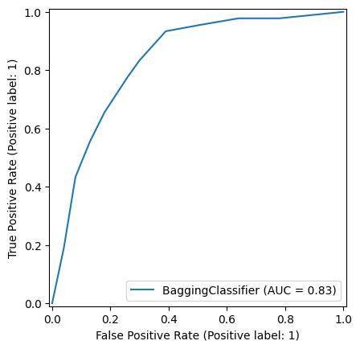

```
Boosting (Original Features) ROC-AUC: 0.7812777777777777
Boosting (Original Features) Accuracy: 0.6684210526315789
Boosting (Original Features) Sensitivity: 0.7333333333333333
Boosting (Original Features) Specificity: 0.61
Boosting (Original Features) Confusion Matrix:
[[61 39]
 [24 66]]
              precision    recall  f1-score   support

           0       0.72      0.61      0.66       100
           1       0.63      0.73      0.68        90

    accuracy                           0.67       190
   macro avg       0.67      0.67      0.67       190
weighted avg       0.68      0.67      0.67       190
```

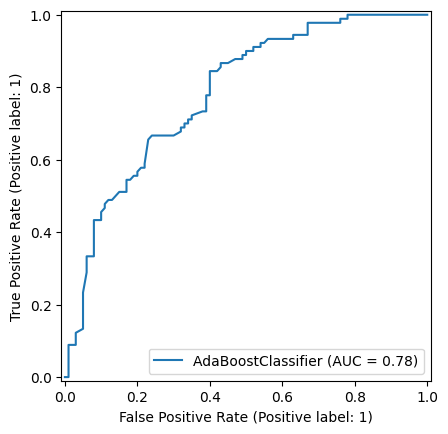

```
Stacking (Original Features) ROC-AUC: 0.8657222222222222
Stacking (Original Features) Accuracy: 0.7894736842105263
Stacking (Original Features) Sensitivity: 0.8777777777777778
Stacking (Original Features) Specificity: 0.71
Stacking (Original Features) Confusion Matrix:
[[71 29]
 [11 79]]
              precision    recall  f1-score   support

           0       0.87      0.71      0.78       100
           1       0.73      0.88      0.80        90

    accuracy                           0.79       190
   macro avg       0.80      0.79      0.79       190
weighted avg       0.80      0.79      0.79       190
```

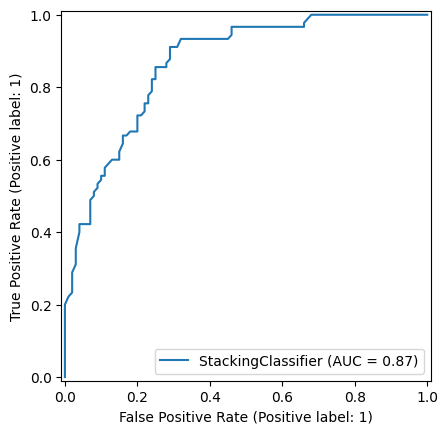

```
Cascading (Original Features) ROC-AUC: 0.8244444444444444
Cascading (Original Features) Accuracy: 0.7526315789473684
Cascading (Original Features) Sensitivity: 0.8
Cascading (Original Features) Specificity: 0.71
Cascading (Original Features) Confusion Matrix:
[[71 29]
 [18 72]]
              precision    recall  f1-score   support

           0       0.80      0.71      0.75       100
           1       0.71      0.80      0.75        90

    accuracy                           0.75       190
   macro avg       0.76      0.76      0.75       190
weighted avg       0.76      0.75      0.75       190
```

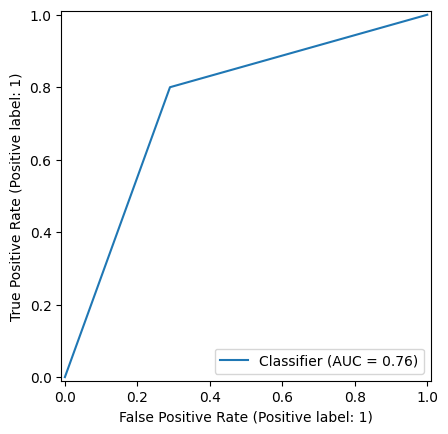

```
Bagging (PCA Features) ROC-AUC: 0.8532054125998225
Bagging (PCA Features) Accuracy: 0.7473684210526316
Bagging (PCA Features) Sensitivity: 0.6956521739130435
Bagging (PCA Features) Specificity: 0.7959183673469388
Bagging (PCA Features) Confusion Matrix:
[[78 20]
 [28 64]]
              precision    recall  f1-score   support

           0       0.74      0.80      0.76        98
           1       0.76      0.70      0.73        92

    accuracy                           0.75       190
   macro avg       0.75      0.75      0.75       190
weighted avg       0.75      0.75      0.75       190
```

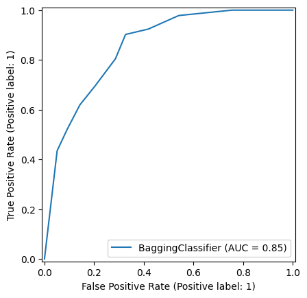

```
Boosting (PCA Features) ROC-AUC: 0.8585292812777285
Boosting (PCA Features) Accuracy: 0.7684210526315789
Boosting (PCA Features) Sensitivity: 0.7717391304347826
Boosting (PCA Features) Specificity: 0.7653061224489796
Boosting (PCA Features) Confusion Matrix:
[[75 23]
 [21 71]]
              precision    recall  f1-score   support

           0       0.78      0.77      0.77        98
           1       0.76      0.77      0.76        92

    accuracy                           0.77       190
   macro avg       0.77      0.77      0.77       190
weighted avg       0.77      0.77      0.77       190
```

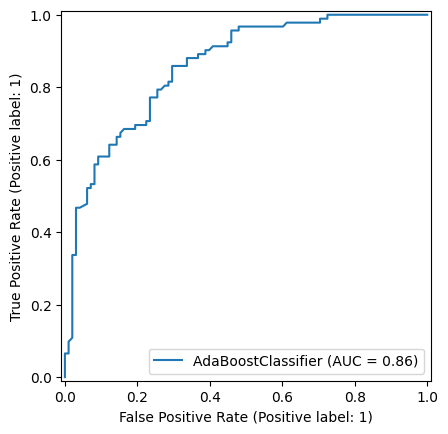

```
Stacking (PCA Features) ROC-AUC: 0.8867014196983142
Stacking (PCA Features) Accuracy: 0.8105263157894737
Stacking (PCA Features) Sensitivity: 0.7934782608695652
Stacking (PCA Features) Specificity: 0.826530612244898
Stacking (PCA Features) Confusion Matrix:
[[81 17]
 [19 73]]
              precision    recall  f1-score   support

           0       0.81      0.83      0.82        98
           1       0.81      0.79      0.80        92

    accuracy                           0.81       190
   macro avg       0.81      0.81      0.81       190
weighted avg       0.81      0.81      0.81       190
```

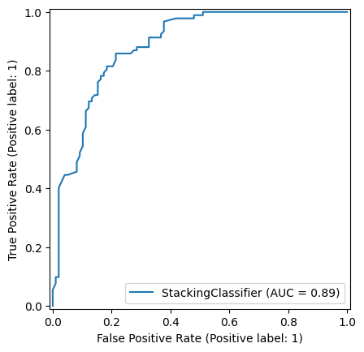

```
Cascading (PCA Features) ROC-AUC: 0.8608030168589175
Cascading (PCA Features) Accuracy: 0.7368421052631579
Cascading (PCA Features) Sensitivity: 0.7717391304347826
Cascading (PCA Features) Specificity: 0.7040816326530612
Cascading (PCA Features) Confusion Matrix:
[[69 29]
 [21 71]]
              precision    recall  f1-score   support

           0       0.77      0.70      0.73        98
           1       0.71      0.77      0.74        92

    accuracy                           0.74       190
   macro avg       0.74      0.74      0.74       190
weighted avg       0.74      0.74      0.74       190
```

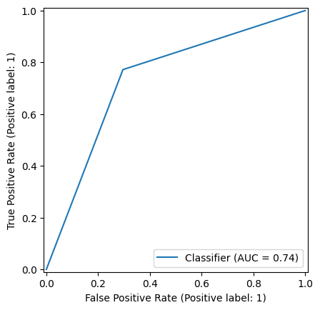

```python
# def a function to evaluate a model
def evaluate_ensemble(model, X, y, model_name):
    y_pred = model.predict(X)
    y_pred = (y_pred>0.5).astype(np.uint8)
    accuracy = accuracy_score(y, y_pred)
    cm = confusion_matrix(y, y_pred)
    sensitivity = cm[1, 1] / (cm[1, 0] + cm[1, 1])
    specificity = cm[0, 0] / (cm[0, 0] + cm[0, 1])
    try:
      roc_auc = roc_auc_score(y, model.predict_proba(X)[:, 1])
      print(f"{model_name} ROC-AUC: {roc_auc}")
    except AttributeError:
      roc_auc = roc_auc_score(y, y_pred)
      print(f"{model_name} ROC-AUC: {roc_auc}")

    print(f"{model_name} Accuracy: {accuracy}")
    print(f"{model_name} Sensitivity: {sensitivity}")
    print(f"{model_name} Specificity: {specificity}")
    print(f"{model_name} Confusion Matrix:\n{cm}")
    print(classification_report(y, y_pred))
    try:
      RocCurveDisplay.from_estimator(model, X, y)
    except AttributeError:
      RocCurveDisplay.from_predictions(y, y_pred)

    plt.show()

estimators = [('dt',DecisionTreeClassifier()),('rf',RandomForestClassifier())]
# Define ensemble models
ensemble_models = [
    ('Bagging', BaggingClassifier(estimator = DecisionTreeClassifier())),
    ('Boosting', AdaBoostClassifier(n_estimators = 50, algorithm="SAMME", random_state = 42)),
    ('Stacking', StackingClassifier(estimators = estimators, final_estimator=LogisticRegression(max_iter = 500))),
    ('Cascading', CascadingClassifier(DecisionTreeClassifier(), LogisticRegression(max_iter = 500)))
]


# Train and evaluate models with original features
for model_name, model in ensemble_models:
    model.fit(X_train_total, y_train_total)
    evaluate_ensemble(model, X_valid_total, y_valid_total, f"{model_name} (Original Features)")



# Train and evaluate models with PCA features
for model_name, model in ensemble_models:
    model.fit(X_train_PCA, y_train_PCA)
    evaluate_ensemble(model, X_valid_PCA, y_valid_PCA, f"{model_name} (PCA Features)")
```

**Anàlisi:** Compara el rendiment de cada mètode utilitzant les mètriques calculades. Discuteix com es comporta cada mètode amb les variables originals en comparació amb les dades transformades per PCA. Discuteix com el PCA afecta el rendiment de cada mètode d’ensemble.

Veiem el mateix que ja hem vist abans on les accuracys de mitjana son millors en pca respecte a les originals pero la millor sensitivity esta a les variables originals en concret tenim els millors resultats a stacking, també es cert que aquest models tenen molta variabilitat ja que tenen motls hyperparametres i segurament podriem arribar a una solucio més optima si miresim tots els models per veure quin es el millor

### **5. Convolutional Neural Network per a Dades Tabulars (1 punt + 1 addicional)**

- 5.1 Què ès una CNN? **CNN** significa **Xarxa Neuronal Convolucional** (en anglès, **Convolutional Neural Network**). És un tipus de xarxa neuronal profunda utilitzada principalment en tasques de **visió per computador**, encara que també s'aplica en altres camps com el processament del llenguatge natural i les sèries temporals.

Una CNN és especialment efectiva per analitzar **imatges** i **dades espacials** perquè pot identificar automàticament **patrons, vores i característiques** en diferents nivells d'abstracció. És a dir, aprèn a detectar característiques simples com línies o colors a les primeres capes i característiques més complexes (cares, objectes, etc.) en capes més profundes.

**Components d'una CNN:**

1. **Capa Convolucional (Convolutional Layer):**  
   Aplica filtres a la imatge d'entrada per extreure característiques com vores, textures o formes.
2. **Funció d'Activació (Activation Function):**  
   Introdueix no linealitat en el model. La més utilitzada és **ReLU (Rectified Linear Unit)**, que elimina valors negatius.
3. **Capa de Pooling (Pooling Layer):**  
   Redueix la dimensionalitat de les característiques extretes, fet que disminueix el temps de càlcul i evita el sobreajustament. El **max-pooling** és el més comú, ja que selecciona el valor màxim dins d’una regió.
4. **Capes Denses (Fully Connected Layers):**  
   Connecten totes les neurones prèvies i generen la sortida final, com ara la classificació d'una imatge (per exemple, gos vs. gat).

### **Exemple d'Aplicació:**

- **Classificació d'Imatges:** Identificació d'objectes en imatges (reconeixement facial, vehicles, etc.).
- **Detecció d'Anomalies:** Reconeixement de patrons anòmals en imatges mèdiques o de seguretat.
- **Reconeixement de Text:** Detecció de caràcters o text manuscrit.
- 5.2. Adaptació de les dades per a utilitzar una CNN

En aquest apartat, transformarem les dades tabulars en una forma que pugui ser processada per un model personalitzat, com ara un **Custom CNN**. Això implica representar les dades tabulars com a "imatges" (matrius en 2D o 3D) per complir amb els requisits d’entrada del model.

5.2.1. Per què és necessari transformar les dades tabulars? Els models convolucionals estan dissenyats per treballar amb dades en forma de matrius (altura, amplada, canals), habitualment per processar imatges. En el cas de les nostres dades:

- Les dades originals tenen **8 característiques** (per exemple, `Glucose`, `BMI`, etc.).
- Les dades PCA tenen **7 components principals**, que són combinacions lineals de les característiques originals.

Com que aquestes característiques són unidimensionals, cal transformar-les perquè el model pugui processar-les com "imatges artificials".

5.2.2. Com es transforma una matriu unidimensional en una "imatge"?

Per convertir les dades tabulars en "imatges", hem de:

1. **Decidir la forma d’entrada (`input_shape`):**
   - Les dades originals amb **8 característiques** es poden reorganitzar en una matriu de **(2 x 4 x 1)** (2 files, 4 columnes i 1 canal).
   - Les dades PCA amb **7 components principals** es poden reorganitzar en una matriu de **(7 x 1 x 1)**.
2. **Validar la forma de les dades:**
   - El nombre total de característiques ha de coincidir amb el producte ( altura x amplada x canals ).
   - Per exemple, per a les dades originals, ( 2 x 4 x 1 = 8 ), que correspon al nombre de característiques.
3. **Aplicar la transformació:**
   - Reorganitzem cada mostra perquè tingui la forma adequada mitjançant un codi personalitzat.

**Implementació:** Aplica els passos anteriorment descrits per a transformar les dades tabulars en imatges:

```python
X_train_total
```

|  | Pregnancies | Glucose | BloodPressure | SkinThickness | Insulin | BMI | DiabetesPedigreeFunction | Age |
| --- | --- | --- | --- | --- | --- | --- | --- | --- |
| 29 | 5 | 117 | 92 | 0 | 0 | 34.100000 | 0.337000 | 38 |
| 535 | 4 | 132 | 0 | 0 | 0 | 32.900000 | 0.302000 | 23 |
| 695 | 7 | 142 | 90 | 24 | 480 | 30.400000 | 0.128000 | 43 |
| 557 | 8 | 110 | 76 | 0 | 0 | 27.800000 | 0.237000 | 58 |
| 836 | 0 | 123 | 70 | 20 | 0 | 27.742918 | 0.282413 | 35 |
| ... | ... | ... | ... | ... | ... | ... | ... | ... |
| 106 | 1 | 96 | 122 | 0 | 0 | 22.400000 | 0.207000 | 27 |
| 270 | 10 | 101 | 86 | 37 | 0 | 45.600000 | 1.136000 | 38 |
| 860 | 1 | 115 | 70 | 29 | 96 | 34.503341 | 0.520052 | 32 |
| 435 | 0 | 141 | 0 | 0 | 0 | 42.400000 | 0.205000 | 29 |
| 102 | 0 | 125 | 96 | 0 | 0 | 22.500000 | 0.262000 | 21 |

- 5.3 Transformació de les dades
1. **Dades originals (8 característiques):** Les dades originals amb 8 característiques es poden reorganitzar en una matriu de (2 x 4 x 1) (2 files, 4 columnes i 1 canal).

**Implementació:** Reorganitza les dades en una matriu de (2x4x1):

```python
X_train_image_original = X_train_total.to_numpy().reshape(-1, *(2, 4, 1))
X_valid_image_original = X_valid_total.to_numpy().reshape(-1, *(2, 4, 1))
```

```python
X_train_image_original.shape
```

```
(760, 2, 4, 1)
```

2. **Dades PCA (7 components principals):** Les dades PCA amb 7 components principals es poden reorganitzar en una matriu de (7 x 1 x 1).

**Implementació:** Reorganitza les dades en una matriu de (7x1x1):

```python
X_train_image_pca = X_train_PCA.to_numpy().reshape(-1, *(7, 1, 1))
X_valid_image_pca = X_valid_PCA.to_numpy().reshape(-1, *(7, 1, 1))
```

[output not shown]

- 5.4. Conversió de dades a float32

**Per què cal convertir les dades a `float32`?**

En l’àmbit de l’aprenentatge automàtic i el processament de dades, és habitual que sigui necessari convertir les dades al format `float32`. Pros:

**Eficiència de memòria**

- **Reducció de l’ús de memòria**: El format `float32` utilitza 4 bytes de memòria, mentre que `float64` (el format predeterminat en moltes llibreries com NumPy o Pandas) utilitza 8 bytes. En conjunts de dades grans, aquesta diferència pot reduir significativament el consum de memòria.
- **Adaptabilitat per a GPUs**: Les GPUs solen treballar amb `float32` de manera nativa. Utilitzar aquest format evita un ús innecessari de memòria i millora l'eficiència computacional.

**Optimització del rendiment**

- **Càlculs més ràpids**: Els càlculs amb `float32` són més ràpids que amb `float64`, especialment en GPUs, ja que moltes eines d’aprenentatge profund (com TensorFlow o PyTorch) estan optimitzades per a `float32`.
- **Temps de transferència reduït**: Transferir dades entre CPU i GPU és més ràpid quan les dades estan en format `float32`, gràcies al menor volum de dades.

**Evitar problemes de compatibilitat**

- **Requisits de les eines**: Moltes eines d’aprenentatge automàtic, com TensorFlow o Keras, esperen que les dades d’entrada estiguin en format `float32`. Si s’utilitza `float64`, es poden generar advertències o errors que obligaran a fer la conversió posteriorment.
- **Models preentrenats**: La majoria dels models preentrenats i operacions en aprenentatge profund estan dissenyats per treballar amb `float32`. Això assegura la compatibilitat i evita desajustos entre tipus de dades.

**Impacte mínim en la precisió**

- **Precisió suficient**: Per a la majoria de tasques d’aprenentatge automàtic, la precisió que ofereix `float32` és més que suficient. Tot i que `float64` proporciona una precisió més alta, aquesta normalment no és necessària en aplicacions pràctiques.
- **Control d’errors**: El format `float32` ajuda a mitigar problemes com desbordaments o subdesbordaments de valors, que poden ser més probables amb `float64`.

**Bones pràctiques en la indústria**

- **Consistència**: Mantenir el mateix tipus de dades en tota la pipeline (entrada, pesos del model, sortides) evita comportaments inesperats o incompatibilitats durant els càlculs.
- **Estàndard**: La majoria de llibreries i eines d’aprenentatge automàtic utilitzen `float32` com a format predeterminat. Això fa que aquest format sigui un estàndard per a garantir la compatibilitat.

**Quan no és necessari convertir a `float32`?**

- **Requisits de precisió alta**: Si l'aplicació requereix càlculs molt precisos (per exemple, simulacions científiques), podria ser més adequat utilitzar `float64`.
- **Conjunts de dades petits**: Si el conjunt de dades és petit i el consum de memòria no és un problema, la conversió pot no ser imprescindible.

Per tant, a l’hora de preparar les dades per a una pipeline d’aprenentatge automàtic, **heu de convertir-les a `float32` per millorar el rendiment, reduir el consum de memòria i garantir la compatibilitat amb les eines modernes.** Això és especialment important si esteu treballant amb conjunts de dades grans o entrenant models en GPUs.

**Implementació:** Converteix les dades originals i pc's a float32

```python
X_train_image_original = X_train_image_original.astype(np.float32)
X_valid_image_original = X_valid_image_original.astype(np.float32)
X_train_image_pca = X_train_image_pca.astype(np.float32)
X_valid_image_pca = X_valid_image_pca.astype(np.float32)
```

- Errors comuns i com evitar-los
1. **Forma d’entrada incorrecta:**
   - Si el nombre de característiques no coincideix amb el producte de la forma d’entrada especificada, apareixerà un error.
   - Solució: Comproveu que el nombre de característiques (n) = (altura x amplada x canals).
2. **Transformació repetida:**
   - Transformar les dades repetidament pot generar errors.
   - Solució: Feu servir només les dades transformades (per exemple, `X_train_original_reshaped`) en entrenaments posteriors.
3. **Diferències en les dimensions entre dades d’entrenament i test:**
   - Si les dades d’entrenament i test tenen dimensions diferents, ResNet50 no podrà processar-les.
   - Solució: Comproveu que la transformació s'aplica de manera consistent a totes les dades.

**Implementació:** Abans d’entrenar el model, assegureu-vos que les dades tenen la forma correcta:

```python
print(X_train_image_pca.shape)
print(X_valid_image_pca.shape)
print(X_train_image_original.shape)
print(X_valid_image_original.shape)
```

```
(760, 7, 1, 1)
(190, 7, 1, 1)
(760, 2, 4, 1)
(190, 2, 4, 1)
```

- 5.5. Entreneu el model utilitzant les dades preprocessades i compareu el rendiment amb els mètodes d'ensemble.

Trains and evaluates CNN adapted for tabular data.

Args:

- X_train: Training data (already reshaped).
- X_test: Testing data (already reshaped).
- y_train: Training labels.
- y_test: Testing labels.
- input_shape: Shape of the input data.
- dataset_type: String indicating whether the dataset is "original" or "pca".
- Prints: evaluation metrics and plots ROC curve.

**Implementació:** Crea la funció per a una CNN personalitzada per a les dades tabulars remodelades en petites estructures semblants a imatges en 2D.

```python
model_original = Sequential()
model_original.add(Conv2D(32, (2, 2), activation='relu', input_shape=(2, 4, 1)))
model_original.add(MaxPooling2D(1,2))
model_original.add(Conv2D(64,(1,2), activation='relu'))
model_original.add(Flatten())
model_original.add(Dense(64, activation='relu'))
model_original.add(Dropout(0.2))

model_original.add(Dense(1,activation='sigmoid'))
model_original.compile(optimizer='adam', loss='binary_crossentropy',metrics=['accuracy'])
model_original.summary()
```

```
Model: "sequential_1"
```

```
┏━━━━━━━━━━━━━━━━━━━━━━━━━━━━━━━━━━━━━━┳━━━━━━━━━━━━━━━━━━━━━━━━━━━━━┳━━━━━━━━━━━━━━━━━┓
┃ Layer (type)                         ┃ Output Shape                ┃         Param # ┃
┡━━━━━━━━━━━━━━━━━━━━━━━━━━━━━━━━━━━━━━╇━━━━━━━━━━━━━━━━━━━━━━━━━━━━━╇━━━━━━━━━━━━━━━━━┩
│ conv2d_2 (Conv2D)                    │ (None, 1, 3, 32)            │             160 │
├──────────────────────────────────────┼─────────────────────────────┼─────────────────┤
│ max_pooling2d_1 (MaxPooling2D)       │ (None, 1, 2, 32)            │               0 │
├──────────────────────────────────────┼─────────────────────────────┼─────────────────┤
│ conv2d_3 (Conv2D)                    │ (None, 1, 1, 64)            │           4,160 │
├──────────────────────────────────────┼─────────────────────────────┼─────────────────┤
│ flatten_1 (Flatten)                  │ (None, 64)                  │               0 │
├──────────────────────────────────────┼─────────────────────────────┼─────────────────┤
│ dense_1 (Dense)                      │ (None, 64)                  │           4,160 │
├──────────────────────────────────────┼─────────────────────────────┼─────────────────┤
│ dropout (Dropout)                    │ (None, 64)                  │               0 │
├──────────────────────────────────────┼─────────────────────────────┼─────────────────┤
│ dense_2 (Dense)                      │ (None, 1)                   │              65 │
└──────────────────────────────────────┴─────────────────────────────┴─────────────────┘
```

```
 Total params: 8,545 (33.38 KB)
```

```
 Trainable params: 8,545 (33.38 KB)
```

```
 Non-trainable params: 0 (0.00 B)
```

```python
model_pca = Sequential()
model_pca.add(Conv2D(32, (1, 1), activation='relu', input_shape=(7, 1, 1)))
model_pca.add(MaxPooling2D(1,2))
model_pca.add(Conv2D(64,(2,1), activation='relu'))
model_pca.add(Flatten())
model_pca.add(Dense(64, activation='relu'))
model_pca.add(Dropout(0.2))

model_pca.add(Dense(1,activation='sigmoid'))
model_pca.compile(optimizer='adam', loss='binary_crossentropy',metrics=['accuracy'])
model_pca.summary()
```

```
Model: "sequential_13"
```

```
┏━━━━━━━━━━━━━━━━━━━━━━━━━━━━━━━━━━━━━━┳━━━━━━━━━━━━━━━━━━━━━━━━━━━━━┳━━━━━━━━━━━━━━━━━┓
┃ Layer (type)                         ┃ Output Shape                ┃         Param # ┃
┡━━━━━━━━━━━━━━━━━━━━━━━━━━━━━━━━━━━━━━╇━━━━━━━━━━━━━━━━━━━━━━━━━━━━━╇━━━━━━━━━━━━━━━━━┩
│ conv2d_17 (Conv2D)                   │ (None, 7, 1, 32)            │              64 │
├──────────────────────────────────────┼─────────────────────────────┼─────────────────┤
│ max_pooling2d_9 (MaxPooling2D)       │ (None, 4, 1, 32)            │               0 │
├──────────────────────────────────────┼─────────────────────────────┼─────────────────┤
│ conv2d_18 (Conv2D)                   │ (None, 3, 1, 64)            │           4,160 │
├──────────────────────────────────────┼─────────────────────────────┼─────────────────┤
│ flatten_10 (Flatten)                 │ (None, 192)                 │               0 │
├──────────────────────────────────────┼─────────────────────────────┼─────────────────┤
│ dense_19 (Dense)                     │ (None, 64)                  │          12,352 │
├──────────────────────────────────────┼─────────────────────────────┼─────────────────┤
│ dropout_9 (Dropout)                  │ (None, 64)                  │               0 │
├──────────────────────────────────────┼─────────────────────────────┼─────────────────┤
│ dense_20 (Dense)                     │ (None, 1)                   │              65 │
└──────────────────────────────────────┴─────────────────────────────┴─────────────────┘
```

```
 Total params: 16,641 (65.00 KB)
```

```
 Trainable params: 16,641 (65.00 KB)
```

```
 Non-trainable params: 0 (0.00 B)
```

**Implementació:** Crea la funciò per a entrenar i avaluar un model CNN personalitzat per a dades tabulars remodelades com a imatges.

[output not shown]

[output cut: 46 more lines]

```
24/24 ━━━━━━━━━━━━━━━━━━━━ 0s 8ms/step - accuracy: 0.8053 - loss: 0.4237 - val_accuracy: 0.7000 - val_loss: 0.5757
24/24 ━━━━━━━━━━━━━━━━━━━━ 0s 6ms/step - accuracy: 0.8155 - loss: 0.4111 - val_accuracy: 0.6947 - val_loss: 0.5916
24/24 ━━━━━━━━━━━━━━━━━━━━ 0s 6ms/step - accuracy: 0.8029 - loss: 0.4203 - val_accuracy: 0.6789 - val_loss: 0.5740
24/24 ━━━━━━━━━━━━━━━━━━━━ 0s 7ms/step - accuracy: 0.7789 - loss: 0.4604 - val_accuracy: 0.6895 - val_loss: 0.6204
24/24 ━━━━━━━━━━━━━━━━━━━━ 0s 7ms/step - accuracy: 0.7830 - loss: 0.4619 - val_accuracy: 0.6895 - val_loss: 0.6005
24/24 ━━━━━━━━━━━━━━━━━━━━ 1s 23ms/step - accuracy: 0.8179 - loss: 0.4226 - val_accuracy: 0.7000 - val_loss: 0.5738
24/24 ━━━━━━━━━━━━━━━━━━━━ 1s 6ms/step - accuracy: 0.7897 - loss: 0.4403 - val_accuracy: 0.6895 - val_loss: 0.5904
24/24 ━━━━━━━━━━━━━━━━━━━━ 0s 6ms/step - accuracy: 0.7635 - loss: 0.4682 - val_accuracy: 0.6947 - val_loss: 0.6015
24/24 ━━━━━━━━━━━━━━━━━━━━ 0s 6ms/step - accuracy: 0.7725 - loss: 0.4604 - val_accuracy: 0.7105 - val_loss: 0.5782
24/24 ━━━━━━━━━━━━━━━━━━━━ 0s 6ms/step - accuracy: 0.7834 - loss: 0.4617 - val_accuracy: 0.7000 - val_loss: 0.5877
24/24 ━━━━━━━━━━━━━━━━━━━━ 0s 6ms/step - accuracy: 0.8360 - loss: 0.4118 - val_accuracy: 0.7053 - val_loss: 0.5892
24/24 ━━━━━━━━━━━━━━━━━━━━ 0s 8ms/step - accuracy: 0.7757 - loss: 0.4610 - val_accuracy: 0.6947 - val_loss: 0.6068
24/24 ━━━━━━━━━━━━━━━━━━━━ 0s 9ms/step - accuracy: 0.8248 - loss: 0.4234 - val_accuracy: 0.6842 - val_loss: 0.6041
24/24 ━━━━━━━━━━━━━━━━━━━━ 0s 12ms/step - accuracy: 0.8003 - loss: 0.4229 - val_accuracy: 0.7105 - val_loss: 0.5908
6/6 - 0s - 16ms/step - accuracy: 0.7105 - loss: 0.5908
```

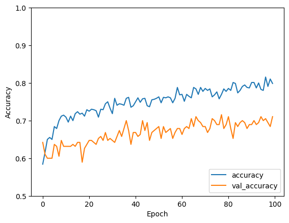

```python
history = model_original.fit(X_train_image_original, y_train_total, epochs=100,
                    validation_data=(X_valid_image_original, y_valid_total))
plt.plot(history.history['accuracy'], label='accuracy')
plt.plot(history.history['val_accuracy'], label = 'val_accuracy')
plt.xlabel('Epoch')
plt.ylabel('Accuracy')
plt.ylim([0.5, 1])
plt.legend(loc='lower right')

test_loss, test_acc = model_original.evaluate(X_valid_image_original,  y_valid_total, verbose=2)
```

[output not shown]

[output cut: 46 more lines]

```
24/24 ━━━━━━━━━━━━━━━━━━━━ 0s 4ms/step - accuracy: 0.7910 - loss: 0.4527 - val_accuracy: 0.6737 - val_loss: 0.7171
24/24 ━━━━━━━━━━━━━━━━━━━━ 0s 4ms/step - accuracy: 0.7861 - loss: 0.4382 - val_accuracy: 0.6579 - val_loss: 0.7262
24/24 ━━━━━━━━━━━━━━━━━━━━ 0s 5ms/step - accuracy: 0.7969 - loss: 0.4268 - val_accuracy: 0.6684 - val_loss: 0.7335
24/24 ━━━━━━━━━━━━━━━━━━━━ 0s 5ms/step - accuracy: 0.8354 - loss: 0.3995 - val_accuracy: 0.6526 - val_loss: 0.7434
24/24 ━━━━━━━━━━━━━━━━━━━━ 0s 5ms/step - accuracy: 0.8079 - loss: 0.4106 - val_accuracy: 0.6947 - val_loss: 0.7148
24/24 ━━━━━━━━━━━━━━━━━━━━ 0s 4ms/step - accuracy: 0.7999 - loss: 0.4358 - val_accuracy: 0.6579 - val_loss: 0.7164
24/24 ━━━━━━━━━━━━━━━━━━━━ 0s 4ms/step - accuracy: 0.8179 - loss: 0.4170 - val_accuracy: 0.6632 - val_loss: 0.7367
24/24 ━━━━━━━━━━━━━━━━━━━━ 0s 5ms/step - accuracy: 0.8159 - loss: 0.4189 - val_accuracy: 0.6684 - val_loss: 0.7106
24/24 ━━━━━━━━━━━━━━━━━━━━ 0s 4ms/step - accuracy: 0.7881 - loss: 0.4160 - val_accuracy: 0.6789 - val_loss: 0.7344
24/24 ━━━━━━━━━━━━━━━━━━━━ 0s 6ms/step - accuracy: 0.8056 - loss: 0.4139 - val_accuracy: 0.6579 - val_loss: 0.7574
24/24 ━━━━━━━━━━━━━━━━━━━━ 0s 6ms/step - accuracy: 0.8221 - loss: 0.4234 - val_accuracy: 0.6684 - val_loss: 0.7437
24/24 ━━━━━━━━━━━━━━━━━━━━ 0s 6ms/step - accuracy: 0.8011 - loss: 0.4105 - val_accuracy: 0.6842 - val_loss: 0.7473
24/24 ━━━━━━━━━━━━━━━━━━━━ 0s 8ms/step - accuracy: 0.8181 - loss: 0.3964 - val_accuracy: 0.6789 - val_loss: 0.7546
24/24 ━━━━━━━━━━━━━━━━━━━━ 0s 6ms/step - accuracy: 0.7962 - loss: 0.4272 - val_accuracy: 0.6842 - val_loss: 0.7547
6/6 - 0s - 8ms/step - accuracy: 0.6842 - loss: 0.7547
```

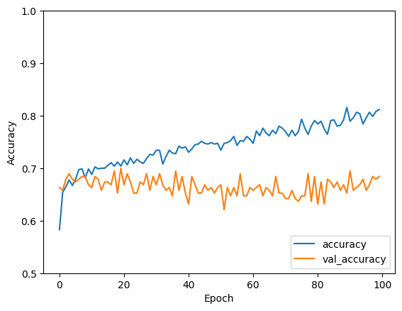

```python
history = model_pca.fit(X_train_image_pca, y_train_PCA, epochs=100,
                    validation_data=(X_valid_image_pca, y_valid_PCA))
plt.plot(history.history['accuracy'], label='accuracy')
plt.plot(history.history['val_accuracy'], label = 'val_accuracy')
plt.xlabel('Epoch')
plt.ylabel('Accuracy')
plt.ylim([0.5, 1])
plt.legend(loc='lower right')

test_loss, test_acc = model_pca.evaluate(X_valid_image_pca,  y_valid_PCA, verbose=2)
```

- 5.6. Avaluació dels models